# PUBG Finish Line Prediction

### *Problem Statement*

In a PUBG game, up to 100 players start in each match (**matchId**). Players (**Id**) can be on teams (**groupId**) which get ranked at the end of the game (**winPlacePerc**) based on how many other teams are still alive when they are eliminated. During the game, players can pick up different amunitions, revive downed-but-not-dead (knocked) teammates, drive vehicles, swim, run, shoot, and experience all of the consequences -- such as falling too far or running themselves over and eliminating themselves. You are provided with a large number of anonymized PUBG game stats, formatted so that each row contains one player's post-game stats. The data comes from matches of all types: solos, duos, squads, and custom; there is no guarantee of there being 100 players per match, nor at most 4 player per group. **Goal:**

Perform the PUBG data analysis and answer the following questions:

- Does killing more people increases the chance of winning the game?
  - **Hint:** Use the correlation between the match winning percentage and number of kills to determine the relationship
- How do we catch the fraudsters in the game?
  - **Hint:** Use various logical conditions based on game knowledge to determine fraudsters in the game
- Can we predict the finishing position of a player in the game?
  - **Hint:** Regression Problem: Train and test a model using regression algorithm to predict the final position of the player at the end of the game. Create a model which **predicts players' finishing placement** based on their final stats, on a scale from 1 (first place) to 0 (last place).

# So Ready to Play! With PYTHONML: Let's Start!

[figure not shown]

```python
import numpy as np
import pandas as pd
import matplotlib.pyplot as plt
from matplotlib import style
style.use('ggplot')
%matplotlib inline
import seaborn as sns
import plotly
import plotly.express as px
import plotly.graph_objects as go
#plt.rcParams['figure.figsize']=17,8
import cufflinks as cf
import plotly.offline as pyo
from plotly.offline import init_notebook_mode,plot,iplot
import folium
import itertools
```

```python
pyo.init_notebook_mode(connected=True)
cf.go_offline()
```

## As the dataset are so large so we have to reduce the datasets without losing the information.

```python
#This algo i have taken from this: https://www.kaggle.com/gemartin/load-data-reduce-memory-usage

def reduce_mem_usage(df):
    """ iterate through all the columns of a dataframe and modify the data type
        to reduce memory usage.
    """
    start_mem = df.memory_usage().sum() / 1024**2

    for col in df.columns:
        col_type = df[col].dtype

        if col_type != object:
            c_min = df[col].min()
            c_max = df[col].max()
            if str(col_type)[:3] == 'int':
                if c_min > np.iinfo(np.int8).min and c_max < np.iinfo(np.int8).max:
                    df[col] = df[col].astype(np.int8)
                elif c_min > np.iinfo(np.int16).min and c_max < np.iinfo(np.int16).max:
                    df[col] = df[col].astype(np.int16)
                elif c_min > np.iinfo(np.int32).min and c_max < np.iinfo(np.int32).max:
                    df[col] = df[col].astype(np.int32)
                elif c_min > np.iinfo(np.int64).min and c_max < np.iinfo(np.int64).max:
                    df[col] = df[col].astype(np.int64)
            else:
                #if c_min > np.finfo(np.float16).min and c_max < np.finfo(np.float16).max:
                #    df[col] = df[col].astype(np.float16)
                #el
                if c_min > np.finfo(np.float32).min and c_max < np.finfo(np.float32).max:
                    df[col] = df[col].astype(np.float32)
                else:
                    df[col] = df[col].astype(np.float64)
        #else:
            #df[col] = df[col].astype('category')

    end_mem = df.memory_usage().sum() / 1024**2
    print('Memory usage of dataframe is {:.2f} MB --> {:.2f} MB (Decreased by {:.1f}%)'.format(
        start_mem, end_mem, 100 * (start_mem - end_mem) / start_mem))
    return df
```

### Load the Dataset

```python
train = pd.read_csv('train_V2.csv')
train = reduce_mem_usage(train)
test = pd.read_csv('test_V2.csv')
test = reduce_mem_usage(test)
print(train.shape, test.shape)
```

```
Memory usage of dataframe is 983.90 MB --> 339.28 MB (Decreased by 65.5%)
Memory usage of dataframe is 413.18 MB --> 140.19 MB (Decreased by 66.1%)
(4446966, 29) (1934174, 28)
```

```python
train.info()
```

```
<class 'pandas.core.frame.DataFrame'>
RangeIndex: 4446966 entries, 0 to 4446965
Data columns (total 29 columns):
Id                 object
groupId            object
matchId            object
assists            int8
boosts             int8
damageDealt        float32
DBNOs              int8
headshotKills      int8
heals              int8
killPlace          int8
killPoints         int16
kills              int8
killStreaks        int8
longestKill        float32
matchDuration      int16
matchType          object
maxPlace           int8
numGroups          int8
rankPoints         int16
revives            int8
rideDistance       float32
roadKills          int8
swimDistance       float32
teamKills          int8
vehicleDestroys    int8
walkDistance       float32
weaponsAcquired    int16
winPoints          int16
winPlacePerc       float32
dtypes: float32(6), int16(5), int8(14), object(4)
memory usage: 339.3+ MB
```

```python
train.head()
```

|  | Id | groupId | matchId | assists | boosts | damageDealt | DBNOs | headshotKills | heals | killPlace | ... | revives | rideDistance | roadKills | swimDistance | teamKills | vehicleDestroys | walkDistance | weaponsAcquired | winPoints | winPlacePerc |
| --- | --- | --- | --- | --- | --- | --- | --- | --- | --- | --- | --- | --- | --- | --- | --- | --- | --- | --- | --- | --- | --- |
| 0 | 7f96b2f878858a | 4d4b580de459be | a10357fd1a4a91 | 0 | 0 | 0.000000 | 0 | 0 | 0 | 60 | ... | 0 | 0.0000 | 0 | 0.00 | 0 | 0 | 244.800003 | 1 | 1466 | 0.4444 |
| 1 | eef90569b9d03c | 684d5656442f9e | aeb375fc57110c | 0 | 0 | 91.470001 | 0 | 0 | 0 | 57 | ... | 0 | 0.0045 | 0 | 11.04 | 0 | 0 | 1434.000000 | 5 | 0 | 0.6400 |
| 2 | 1eaf90ac73de72 | 6a4a42c3245a74 | 110163d8bb94ae | 1 | 0 | 68.000000 | 0 | 0 | 0 | 47 | ... | 0 | 0.0000 | 0 | 0.00 | 0 | 0 | 161.800003 | 2 | 0 | 0.7755 |
| 3 | 4616d365dd2853 | a930a9c79cd721 | f1f1f4ef412d7e | 0 | 0 | 32.900002 | 0 | 0 | 0 | 75 | ... | 0 | 0.0000 | 0 | 0.00 | 0 | 0 | 202.699997 | 3 | 0 | 0.1667 |
| 4 | 315c96c26c9aac | de04010b3458dd | 6dc8ff871e21e6 | 0 | 0 | 100.000000 | 0 | 0 | 0 | 45 | ... | 0 | 0.0000 | 0 | 0.00 | 0 | 0 | 49.750000 | 2 | 0 | 0.1875 |

5 rows × 29 columns

```python
train.isnull()
```

[output not shown]

4446966 rows × 29 columns

```python
train.isnull().sum()
```

```
Id                 0
groupId            0
matchId            0
assists            0
boosts             0
damageDealt        0
DBNOs              0
headshotKills      0
heals              0
killPlace          0
killPoints         0
kills              0
killStreaks        0
longestKill        0
matchDuration      0
matchType          0
maxPlace           0
numGroups          0
rankPoints         0
revives            0
rideDistance       0
roadKills          0
swimDistance       0
teamKills          0
vehicleDestroys    0
walkDistance       0
weaponsAcquired    0
winPoints          0
winPlacePerc       1
dtype: int64
```

```python
train.tail()
```

|  | Id | groupId | matchId | assists | boosts | damageDealt | DBNOs | headshotKills | heals | killPlace | ... | revives | rideDistance | roadKills | swimDistance | teamKills | vehicleDestroys | walkDistance | weaponsAcquired | winPoints | winPlacePerc |
| --- | --- | --- | --- | --- | --- | --- | --- | --- | --- | --- | --- | --- | --- | --- | --- | --- | --- | --- | --- | --- | --- |
| 4446961 | afff7f652dbc10 | d238e426f50de7 | 18492834ce5635 | 0 | 0 | 0.000000 | 0 | 0 | 0 | 74 | ... | 0 | 1292.0 | 0 | 0.000 | 0 | 0 | 1019.000000 | 3 | 1507 | 0.1786 |
| 4446962 | f4197cf374e6c0 | 408cdb5c46b2ac | ee854b837376d9 | 0 | 1 | 44.150002 | 0 | 0 | 0 | 69 | ... | 0 | 0.0 | 0 | 0.000 | 0 | 0 | 81.699997 | 6 | 0 | 0.2935 |
| 4446963 | e1948b1295c88a | e26ac84bdf7cef | 6d0cd12784f1ab | 0 | 0 | 59.060001 | 0 | 0 | 0 | 66 | ... | 0 | 0.0 | 0 | 2.184 | 0 | 0 | 788.700012 | 4 | 0 | 0.4815 |
| 4446964 | cc032cdd73b7ac | c2223f35411394 | c9c701d0ad758a | 0 | 4 | 180.399994 | 1 | 1 | 2 | 11 | ... | 2 | 0.0 | 0 | 0.000 | 0 | 0 | 2748.000000 | 8 | 0 | 0.8000 |
| 4446965 | 0d8e7ed728b6fd | 8c74f72fedf5ff | 62a16aabcc095c | 0 | 2 | 268.000000 | 0 | 0 | 1 | 18 | ... | 0 | 1369.0 | 0 | 0.000 | 0 | 0 | 1244.000000 | 5 | 0 | 0.5464 |

5 rows × 29 columns

## Part 1: Exploratory Data Analysis

## Part 2: Data Cleaning: Outlier Detection and Removal - Finding the fraudsters

## Part 3: Feature Engineering

## Part 4: Final Predition

## Part 1: Exploratory Data Analysis

```python
for i in ['Id','groupId','matchId']:
    print(f'unique [{i}] count:', train[i].nunique())
```

```
unique [Id] count: 4446966
unique [groupId] count: 2026745
unique [matchId] count: 47965
```

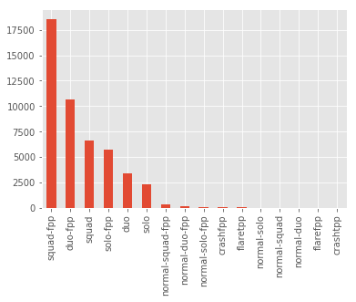

```python
train.groupby('matchId')['matchType'].first().value_counts().plot(kind='bar')
```

```python
train.groupby('matchId')['matchType'].first().value_counts().iplot(kind='bar')
```

[interactive chart not shown]

[interactive chart not shown]

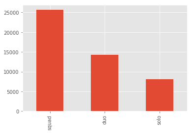

```python
map = lambda x: 'solo' if ('solo' in x) else 'duo' if ('duo' in x) or ('crash' in x) else 'squad'
train['matchType'] = train['matchType'].apply(map)
train.groupby('matchId')['matchType'].first().value_counts().plot(kind='bar')
train.groupby('matchId')['matchType'].first().value_counts().iplot(kind='bar')
```

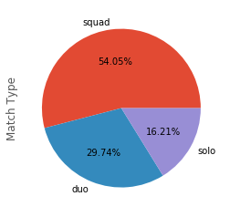

```python
# This pie-plot shows that generally people love to play in squad
from itertools import chain
from collections import Counter
cts = Counter(chain.from_iterable(train.matchType.str.split('|').values))
_ = plt.pie(cts.values(), labels=cts.keys(), autopct='%0.2f%%')
_ = plt.ylabel('Match Type')
```

```python
df=train.groupby('matchType')['kills'].sum().sort_values(ascending=False).reset_index()
```

```python
df
```

|  | matchType | kills |
| --- | --- | --- |
| 0 | squad | 2212798.0 |
| 1 | duo | 1224476.0 |
| 2 | solo | 675206.0 |

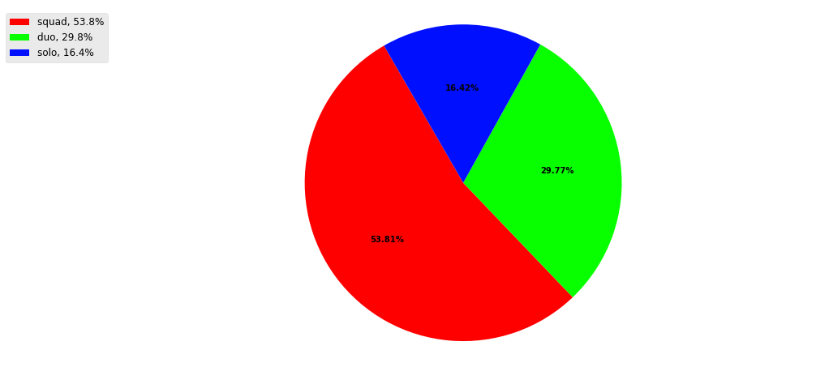

```python
# This pie-plot shows that while playing in squad we got most of the kills!!
# This plot is between the matchtypes vs no. of kills!!
# The below code is for building a table with the pie-plot!!
def autopct_generator(limit):
    def inner_autopct(pct):
        return ('%.2f%%' % pct) if pct > limit else ''
    return inner_autopct
labels =df['matchType']
sizes = df['kills']
fig1, ax1 = plt.subplots(figsize=(6, 6))
fig1.subplots_adjust(0.3,0,2,1)
box = ax1.get_position()
theme = plt.get_cmap('hsv')
ax1.set_prop_cycle("color", [theme(1. * i / len(sizes)) for i in range(len(sizes))])
ax1.set_position([box.x0, box.y0, box.width * 1.2, box.height])
_, _, autotexts = ax1.pie(
    sizes, autopct=autopct_generator(7), startangle=120, radius=1.8 * 1000)
for autotext in autotexts:
    autotext.set_weight('bold')
ax1.axis('equal')
total = sum(sizes)
plt.legend(
    loc='upper left',
    labels=['%s, %1.1f%%' % (
        l, (float(s) / total) * 100) for l, s in zip(labels, sizes)],
    prop={'size': 12},
    bbox_to_anchor=(0.0, 1),
    bbox_transform=fig1.transFigure
)
```

## PUBG Kills

[figure not shown]

```python
# Find the Id's with Maximum kills
df_1=train.groupby(['Id','matchType'])['kills'].sum().sort_values(ascending=False).reset_index()
```

```python
df_1.head(10)
```

|  | Id | matchType | kills |
| --- | --- | --- | --- |
| 0 | 06308c988bf0c2 | squad | 72 |
| 1 | 80ac0bbf58bfaf | solo | 66 |
| 2 | 810f2379261545 | solo | 65 |
| 3 | da31f191ace8ed | duo | 57 |
| 4 | 2a4c8d7cdb0361 | duo | 57 |
| 5 | 7f3edd982813e6 | solo | 56 |
| 6 | 1f6ceaa5140fb6 | solo | 56 |
| 7 | f83f0bfaafb7d8 | squad | 55 |
| 8 | 2ade4369bccd12 | solo | 55 |
| 9 | 9b5bcc3a3dd42a | squad | 53 |

```python
# Trace data (Id vs kills)!!
trace = go.Table(
    domain=dict(x=[0, 0.52],
                y=[0, 1.0]),
    header=dict(values=["Id","matchType","kills"],
                fill = dict(color = 'green'),
                font = dict(color = 'white', size = 14),
                align = ['center'],
               height = 30),
    cells=dict(values=[df_1['Id'].head(10),df_1['matchType'].head(10),df_1['kills'].head(10)],
               fill = dict(color = ['lightgreen', 'white']),
               align = ['center']))

trace1 = go.Bar(x=df_1['Id'].head(10),
                y=df_1["kills"].head(10),
                xaxis='x1',
                yaxis='y1',
                marker=dict(color='magenta'),opacity=0.60)
layout = dict(
    width=830,
    height=410,
    autosize=False,
    title='Players with maximum kills',
    showlegend=False,
    xaxis1=dict(**dict(domain=[0.58, 1], anchor='y1', showticklabels=True)),
    yaxis1=dict(**dict(domain=[0, 1.0], anchor='x1', hoverformat='.2f')),
)

fig1 = dict(data=[trace, trace1], layout=layout)
iplot(fig1)
```

[interactive chart not shown]

### HURRAY!! we have find the best Ids according to number of kills. But does No. of kills helps us to increase the chance of Win.The Answer is YES!!

### Now let's check the Id's Knocked out during the game most of the times, by the column *DBNOs (Down but not out)*

[figure not shown]

```python
df_knock=train.groupby(['Id','matchType'])['DBNOs'].sum().sort_values(ascending=False).reset_index()
```

```python
df_knock.head(10)
```

|  | Id | matchType | DBNOs |
| --- | --- | --- | --- |
| 0 | f83f0bfaafb7d8 | squad | 53 |
| 1 | 770c02791306c4 | squad | 40 |
| 2 | f699c842c5dfab | squad | 39 |
| 3 | ef9f4290f1f917 | squad | 39 |
| 4 | dd424a8b74bd49 | squad | 38 |
| 5 | c5e6859543ef63 | squad | 35 |
| 6 | 669d797ea7b76d | squad | 33 |
| 7 | cb77d9af81d0bf | squad | 33 |
| 8 | d54ee6696e79fe | squad | 33 |
| 9 | 405dc99e21822f | squad | 33 |

```python
# Trace data (Id vs Knockout)!!
trace = go.Table(
    domain=dict(x=[0, 0.52],
                y=[0, 1.0]),
    header=dict(values=["Id","matchType","DBNOs"],
                fill = dict(color = 'red'),
                font = dict(color = 'white', size = 13),
                align = ['center'],
               height = 30),
    cells=dict(values=[df_knock['Id'].head(10),df_knock['matchType'].head(10),df_knock['DBNOs'].head(10)],
               fill = dict(color = ['lightsalmon', 'white']),
               align = ['center']))

trace1 = go.Bar(x=df_knock['Id'].head(10),
                y=df_knock["DBNOs"].head(10),
                xaxis='x1',
                yaxis='y1',
                marker=dict(color='blue'),opacity=0.60)
layout = dict(
    width=830,
    height=430,
    autosize=False,
    title='Players with maximum Time Knock out',
    showlegend=False,
    xaxis1=dict(**dict(domain=[0.58, 1], anchor='y1', showticklabels=True)),
    yaxis1=dict(**dict(domain=[0, 1.0], anchor='x1', hoverformat='.2f')),
)

fig1 = dict(data=[trace, trace1], layout=layout)
iplot(fig1)
```

[interactive chart not shown]

```python
def mergeList(list1,list2):
    return list(itertools.product(list1,list2))
match = train.groupby(['matchType','matchId']).size().to_frame('players in match')
group = train.groupby(['matchType','matchId','groupId']).size().to_frame('players in group')
pd.concat([match.groupby('matchType').describe()[mergeList(['players in match'],['min','mean','max'])],
           group.groupby('matchType').describe()[mergeList(['players in group'],['min','mean','max'])]], axis=1)
```

| matchType | players in match min | players in match mean | players in match max | players in group min | players in group mean | players in group max |
| --- | --- | --- | --- | --- | --- | --- |
| duo | 7.0 | 92.985658 | 100.0 | 1.0 | 2.050456 | 72.0 |
| solo | 1.0 | 89.031872 | 100.0 | 1.0 | 1.039249 | 64.0 |
| squad | 5.0 | 93.723193 | 100.0 | 1.0 | 3.492575 | 74.0 |

```python
subset = train[train['matchId']=='3e029737889ce9']
sub_grp = subset[subset['groupId']=='b8275198faa03b']

print('matchId ==\'3e029737889ce9\' & groupId ==\'b8275198faa03b\'')
print('players:',len(subset))
print('groups:',subset['groupId'].nunique())
print('numGroups:',subset['numGroups'].unique())
print('maxPlace:',subset['maxPlace'].unique())
print('max-group players:',len(sub_grp))
print('max-group winPlacePerc:',sub_grp['winPlacePerc'].unique())
print('winPlacePerc:',subset['winPlacePerc'].sort_values().unique())
```

```
matchId =='3e029737889ce9' & groupId =='b8275198faa03b'
players: 99
groups: 14
numGroups: [14]
maxPlace: [50]
max-group players: 72
max-group winPlacePerc: [0.2449]
winPlacePerc: [0.         0.0204     0.0408     0.0612     0.0816     0.102
 0.1224     0.16329999 0.1837     0.2041     0.2245     0.2449
 0.51020002 1.        ]
```

# Check correlation of the feature with Winning Percentage

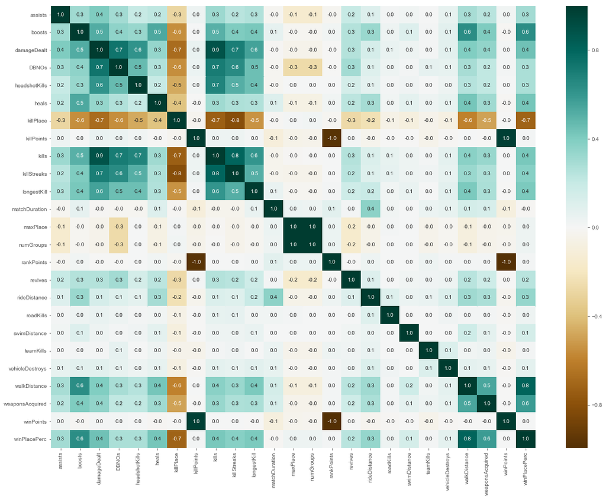

```python
corr = train.corr()
f,ax = plt.subplots(figsize=(20, 15))
sns.heatmap(train.corr(), annot=True, fmt= '.1f',ax=ax, cmap="BrBG")
sns.set(font_scale=1.25)
plt.show()
```

# Analyzing the Kills

[figure not shown]

```python
print("On an average a person kills {:.4f} players, 99% of people have {} kills or less, while the maximum kills ever recorded is {}.".format(train['kills'].mean(),train['kills'].quantile(0.99), train['kills'].max()))
```

```
On an average a person kills 0.9248 players, 99% of people have 7.0 kills or less, while the maximum kills ever recorded is 72.
```

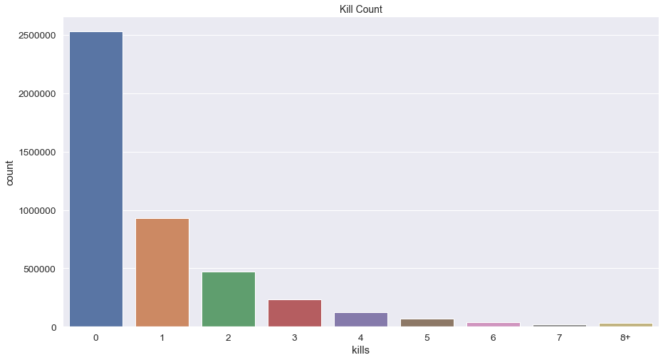

```python
data = train.copy()
data.loc[data['kills'] > data['kills'].quantile(0.99)] = '8+'
plt.figure(figsize=(15,8))
sns.countplot(data['kills'].astype('str').sort_values())
plt.title("Kill Count",fontsize=14)
plt.show()
```

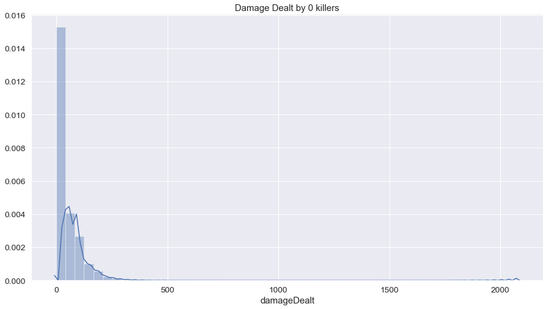

```python
data = train.copy()
data = data[data['kills']==0]
plt.figure(figsize=(15,8))
plt.title("Damage Dealt by 0 killers",fontsize=15)
sns.distplot(data['damageDealt'])
plt.show()
```

```python
print("A total of {} players ({:.4f}%) have won without a single kill!".format(len(data[data['winPlacePerc']==1]), 100*len(data[data['winPlacePerc']==1])/len(train)))
data1 = train[train['damageDealt'] == 0].copy()
print("A total of {} players ({:.4f}%) have won without dealing damage!".format(len(data1[data1['winPlacePerc']==1]), 100*len(data1[data1['winPlacePerc']==1])/len(train)))
```

```
A total of 16666 players (0.3748%) have won without a single kill!
A total of 4770 players (0.1073%) have won without dealing damage!
```

## *More kills usually means a player is better skilled and will rank closer to the top*.

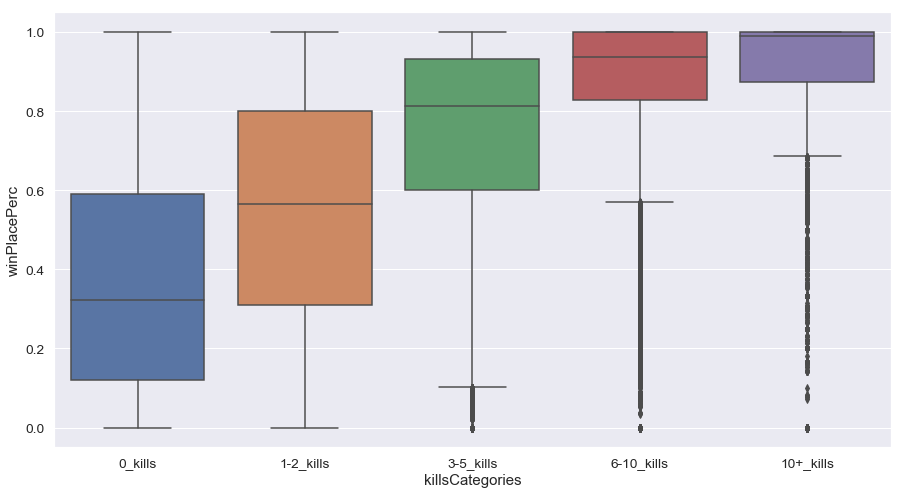

```python
kills = train.copy()
kills['killsCategories'] = pd.cut(kills['kills'], [-1, 0, 2, 5, 10, 60], labels=['0_kills','1-2_kills', '3-5_kills', '6-10_kills', '10+_kills'])
plt.figure(figsize=(15,8))
sns.boxplot(x="killsCategories", y="winPlacePerc", data=kills)
plt.show()
```

# Analysing Runnning

[figure not shown]

```python
print("{} players ({:.4f}%) walked 0 meters. This means that either they die before even taking a step or they have just joined the game but are away from keyboard (more possible).".format(len(data[data['walkDistance'] == 0]), 100*len(data1[data1['walkDistance']==0])/len(train)))
```

```
98054 players (2.0329%) walked 0 meters. This means that either they die before even taking a step or they have just joined the game but are away from keyboard (more possible).
```

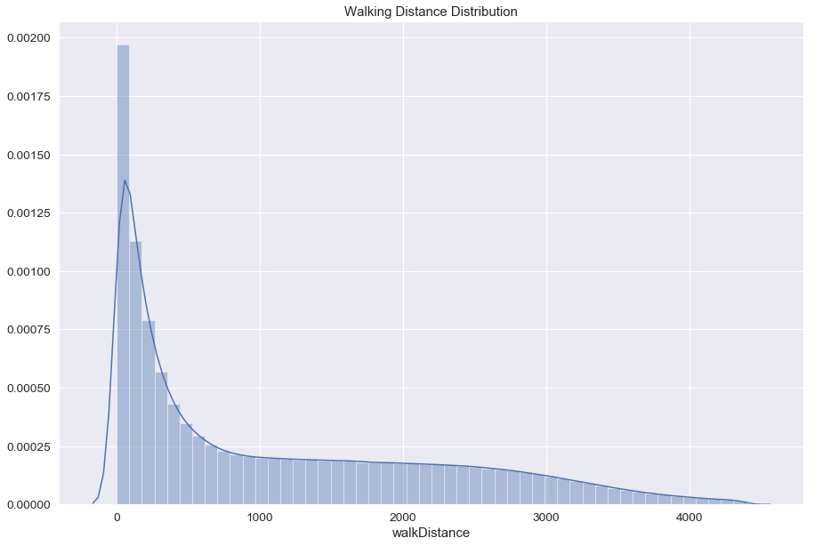

```python
data = train.copy()
data = data[data['walkDistance'] < train['walkDistance'].quantile(0.99)]
plt.figure(figsize=(15,10))
plt.title("Walking Distance Distribution",fontsize=15)
sns.distplot(data['walkDistance'])
plt.show()
```

# Analysing Running: Effect of running on winning

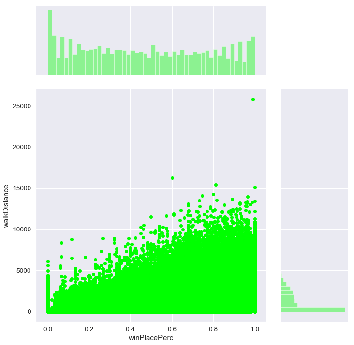

```python
sns.jointplot(x="winPlacePerc", y="walkDistance",  data=train, height=10, ratio=3, color="lime")
plt.show()
```

# Analysing Riding

```python
print("An average person drives for {:.1f}m, 99% of people have drived {}m or less, while THE RIDER rode for {}m.".format(train['rideDistance'].mean(), train['rideDistance'].quantile(0.99), train['rideDistance'].max()))
```

```
An average person drives for 606.1m, 99% of people have drived 6966.0m or less, while THE RIDER rode for 40710.0m.
```

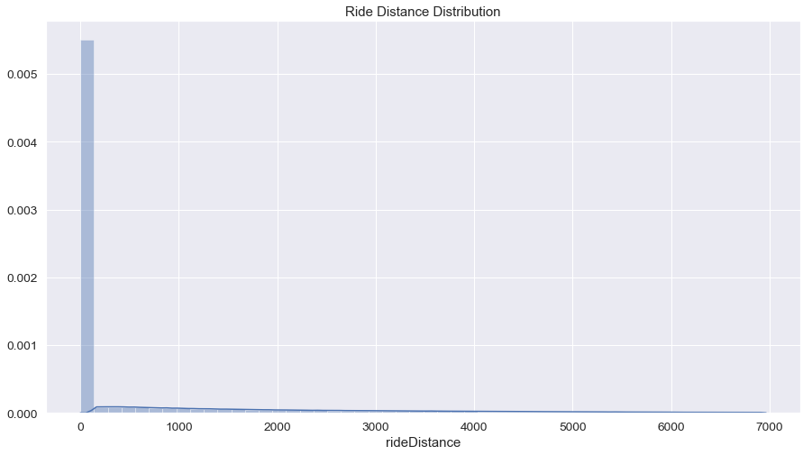

```python
data = train.copy()
data = data[data['rideDistance'] < train['rideDistance'].quantile(0.99)]
plt.figure(figsize=(15,8))
plt.title("Ride Distance Distribution",fontsize=15)
sns.distplot(data['rideDistance'])
plt.show()
```

# Analysing Riding: Effect of Riding on winning

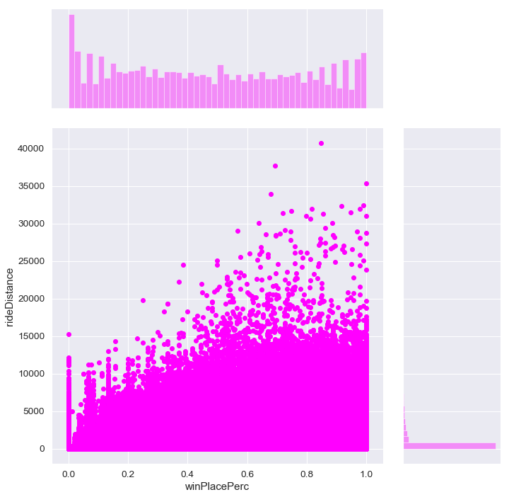

```python
sns.jointplot(x="winPlacePerc", y="rideDistance", data=train, height=10, ratio=3, color="magenta")
plt.show()
```

## Generally there is a theory that if a player is able to destroy a vehicle he/she is skilled. Let's Check!!

[figure not shown]

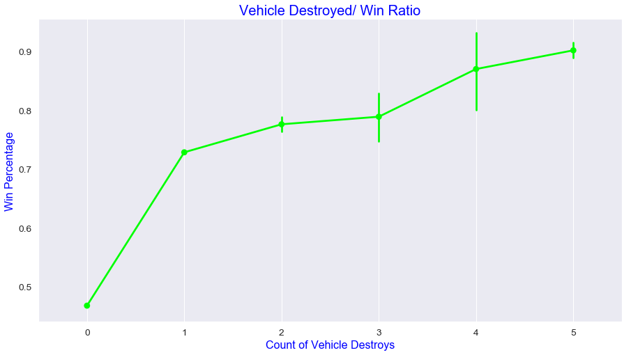

```python
f,ax1 = plt.subplots(figsize =(15,8))
sns.pointplot(x='vehicleDestroys',y='winPlacePerc',data=data,color='lime',alpha=0.5)
plt.xlabel('Count of Vehicle Destroys',fontsize = 16,color='blue')
plt.ylabel('Win Percentage',fontsize = 16,color='blue')
plt.title('Vehicle Destroyed/ Win Ratio',fontsize = 20,color='blue')
plt.grid()
plt.show()
```

#### Hence It concludes Destroying vehicles enhances the chances of winning

## Analysing Healing and Boosting

```python
print("In the game on an average a person uses {:.1f} heal items, 99% of people use {} or less, while the max heals by the player used {}.".format(train['heals'].mean(), train['heals'].quantile(0.99), train['heals'].max()))
print("In the game on an average a person uses {:.1f} boost items, 99% of people use {} or less, while the the max boosts by the player used {}.".format(train['boosts'].mean(), train['boosts'].quantile(0.99), train['boosts'].max()))
```

```
In the game on an average a person uses 1.4 heal items, 99% of people use 12.0 or less, while the max heals by the player used 80.
In the game on an average a person uses 1.1 boost items, 99% of people use 7.0 or less, while the the max boosts by the player used 33.
```

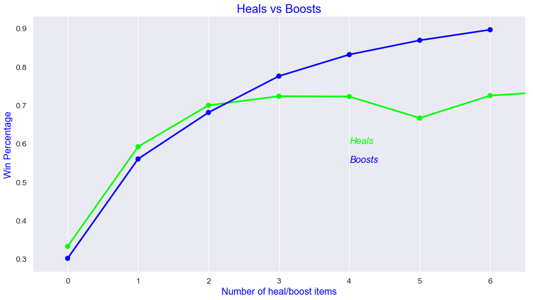

```python
data = train.copy()
data = data[data['heals'] < data['heals'].quantile(0.99)]
data = data[data['boosts'] < data['boosts'].quantile(0.99)]
f,ax1 = plt.subplots(figsize =(15,8))
sns.pointplot(x='heals',y='winPlacePerc',data=data,color='lime',alpha=0.8)
sns.pointplot(x='boosts',y='winPlacePerc',data=data,color='blue',alpha=0.8)
plt.text(4,0.6,'Heals',color='lime',fontsize = 16,style = 'italic')
plt.text(4,0.55,'Boosts',color='blue',fontsize = 16,style = 'italic')
plt.xlabel('Number of heal/boost items',fontsize = 16,color='blue')
plt.ylabel('Win Percentage',fontsize = 16,color='blue')
plt.title('Heals vs Boosts',fontsize = 20,color='blue')
plt.grid()
plt.show()
```

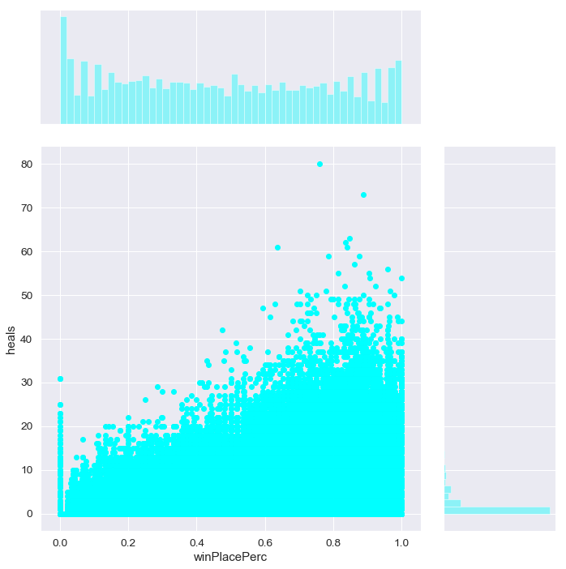

```python
sns.jointplot(x="winPlacePerc", y="heals", data=train, height=10, ratio=3, color="cyan")
plt.show()
```

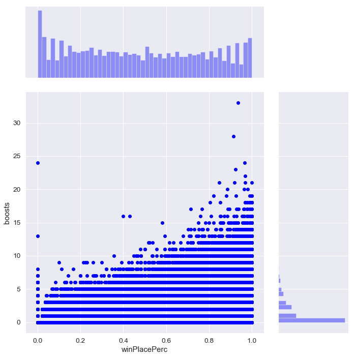

```python
sns.jointplot(x="winPlacePerc", y="boosts", data=train, height=10, ratio=3, color="blue")
plt.show()
```

```python
solos=train[train['matchType']=='solo']
duos=train[train['matchType']=='duo']
squads=train[train['matchType']=='squad']
```

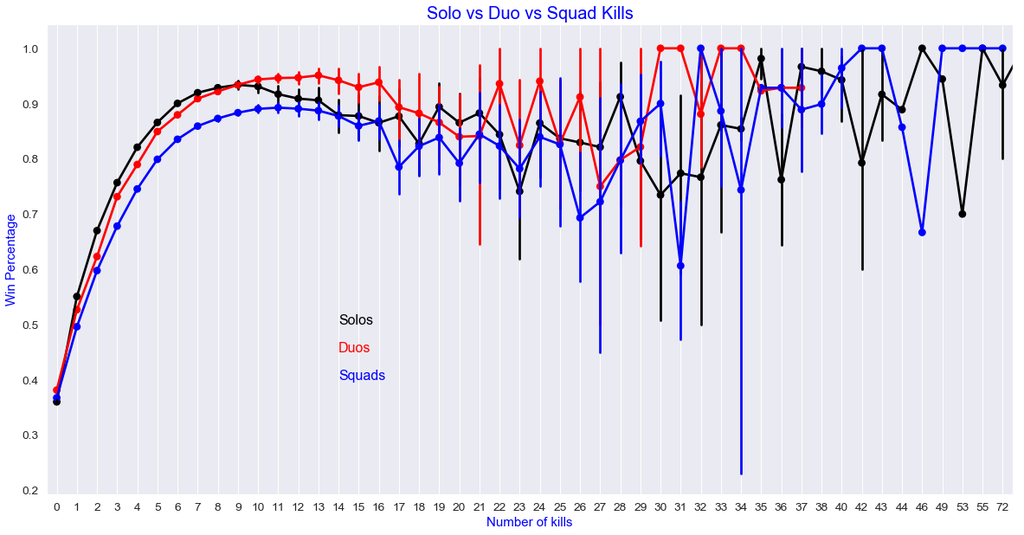

```python
f,ax1 = plt.subplots(figsize =(20,10))
sns.pointplot(x='kills',y='winPlacePerc',data=solos,color='black',alpha=0.6)
sns.pointplot(x='kills',y='winPlacePerc',data=duos,color='red',alpha=0.6)
sns.pointplot(x='kills',y='winPlacePerc',data=squads,color='blue',alpha=0.6)
plt.text(14,0.5,'Solos',color='black',fontsize = 16)
plt.text(14,0.45,'Duos',color='red',fontsize = 16)
plt.text(14,0.4,'Squads',color='blue',fontsize = 16)
plt.xlabel('Number of kills',fontsize = 15,color='blue')
plt.ylabel('Win Percentage',fontsize = 15,color='blue')
plt.title('Solo vs Duo vs Squad Kills',fontsize = 20,color='blue')
plt.grid()
plt.show()
```

## Let's check how Assisting or Reviving have the effect on the winning percentage.

```python
revive=train.groupby(['Id','winPlacePerc'])['assists'].sum().sort_values(ascending=False).reset_index()
```

```python
head=revive.head(10)
```

```python
head
```

|  | Id | winPlacePerc | assists |
| --- | --- | --- | --- |
| 0 | be4ff9afaa5bb1 | 0.8000 | 22 |
| 1 | 746aa7eabf7c86 | 0.7000 | 21 |
| 2 | 810f2379261545 | 1.0000 | 20 |
| 3 | a0acd251db3984 | 0.3333 | 17 |
| 4 | 1a651de43d5a18 | 0.5000 | 17 |
| 5 | 5cc23af7400983 | 0.7143 | 15 |
| 6 | 6bae3404d61d0a | 0.3571 | 15 |
| 7 | 1f6ceaa5140fb6 | 0.9000 | 15 |
| 8 | e494d51ebabbf2 | 1.0000 | 15 |
| 9 | d9a95cf9d47d96 | 0.6667 | 15 |

```python
px.scatter(head,x='Id',y='winPlacePerc')
```

[interactive chart not shown]

```python
head.iplot(kind='scatter',mode='markers+lines',x='Id',y='winPlacePerc',title='IDs Reviving vs Winning %')
```

[interactive chart not shown]

# Part-2: Outlier Detection and Removal- Finding Hackers In Pubg

```python
# We have detected a NULL Value in the column winPlacePerc at the starting of the project, So now drop that NAN Value
train.drop(train[train['winPlacePerc'].isnull()].index, inplace=True)
```

```python
# Now Check row if it consits a NaN value
train[train['winPlacePerc'].isnull()]
```

|  | Id | groupId | matchId | assists | boosts | damageDealt | DBNOs | headshotKills | heals | killPlace | ... | revives | rideDistance | roadKills | swimDistance | teamKills | vehicleDestroys | walkDistance | weaponsAcquired | winPoints | winPlacePerc |
| --- | --- | --- | --- | --- | --- | --- | --- | --- | --- | --- | --- | --- | --- | --- | --- | --- | --- | --- | --- | --- | --- |

0 rows × 29 columns

# Anomalies in Killing: Aim Hacks

```python
# Engineer a new feature _totalDistance
train['_totalDistance'] = train['rideDistance'] + train['walkDistance'] + train['swimDistance']
```

#### We see that the most players score in the 0 to 10% region. However, there are a few anomalies that have a headshot_rate of 100% percent with more than 9 kills!

```python
# Engineer _headshot_rate feature --- headshots made per kill
train['_headshot_rate'] = train['headshotKills'] / train['kills']
train['_headshot_rate'] = train['_headshot_rate'].fillna(0)
```

```python
def show_countplot(column):
    plt.figure(figsize=(15,8))
    sns.countplot(data=train, x=column).set_title(column)
    plt.show()

def show_distplot(column):
    plt.figure(figsize=(15, 8))
    sns.distplot(train[column], bins=50)
    plt.show()
```

## Inhumane kills: Is it possible to kill more than 40 kills, Of course they are HACKERS!!!

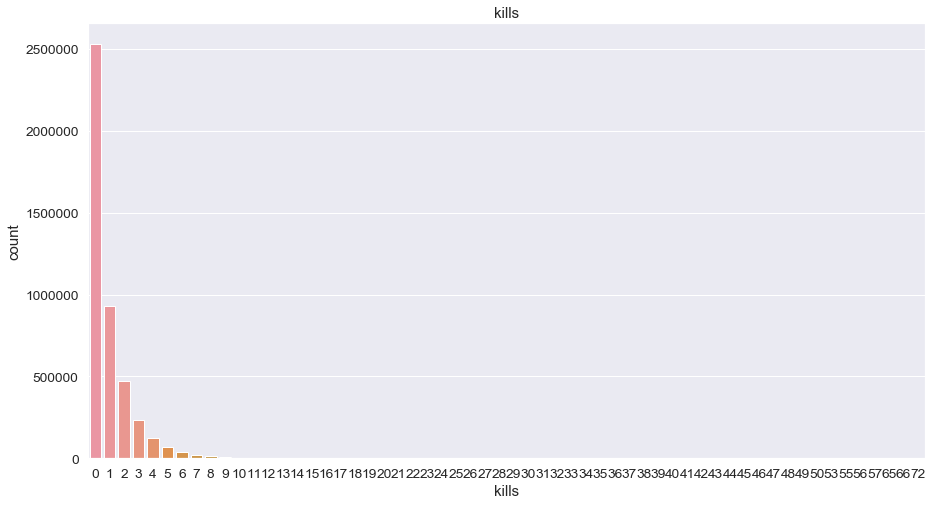

```python
show_countplot('kills')
```

```python
train[(train['kills'] >= 40) & (train['weaponsAcquired'] > 55) & (train['_totalDistance'] < 100.0)]
```

|  | Id | groupId | matchId | assists | boosts | damageDealt | DBNOs | headshotKills | heals | killPlace | ... | roadKills | swimDistance | teamKills | vehicleDestroys | walkDistance | weaponsAcquired | winPoints | winPlacePerc | _totalDistance | _headshot_rate |
| --- | --- | --- | --- | --- | --- | --- | --- | --- | --- | --- | --- | --- | --- | --- | --- | --- | --- | --- | --- | --- | --- |
| 156599 | 746aa7eabf7c86 | 5723e7d8250da3 | f900de1ec39fa5 | 21 | 0 | 5479.0 | 0 | 12 | 7 | 4 | ... | 0 | 0.0 | 0 | 0 | 23.709999 | 61 | 0 | 0.7000 | 23.709999 | 0.250000 |
| 672993 | da31f191ace8ed | ce9a3c4950a8f2 | 17dea22cefe62a | 10 | 0 | 5793.0 | 0 | 5 | 2 | 1 | ... | 0 | 0.0 | 0 | 0 | 24.270000 | 56 | 0 | 1.0000 | 24.270000 | 0.087719 |
| 770454 | 2ade4369bccd12 | 9f9e64a3db8384 | e024bf51bf1799 | 12 | 0 | 5557.0 | 0 | 7 | 4 | 1 | ... | 0 | 0.0 | 0 | 0 | 85.550003 | 66 | 0 | 1.0000 | 85.550003 | 0.127273 |
| 1378200 | f241fdbb4f94c6 | fadbbc4cbb3e06 | e024bf51bf1799 | 9 | 0 | 3707.0 | 0 | 5 | 1 | 5 | ... | 0 | 0.0 | 0 | 0 | 46.709999 | 72 | 0 | 0.7778 | 46.709999 | 0.121951 |

4 rows × 31 columns

```python
# Is it even possible to kill more than 40 people without using any heals?
train[(train['kills'] >= 40) & (train['heals'] == 0)]
```

|  | Id | groupId | matchId | assists | boosts | damageDealt | DBNOs | headshotKills | heals | killPlace | ... | roadKills | swimDistance | teamKills | vehicleDestroys | walkDistance | weaponsAcquired | winPoints | winPlacePerc | _totalDistance | _headshot_rate |
| --- | --- | --- | --- | --- | --- | --- | --- | --- | --- | --- | --- | --- | --- | --- | --- | --- | --- | --- | --- | --- | --- |
| 160254 | 15622257cb44e2 | 1a513eeecfe724 | db413c7c48292c | 1 | 0 | 4033.0 | 0 | 40 | 0 | 1 | ... | 0 | 0.0 | 1 | 0 | 718.299988 | 16 | 1500 | 1.0 | 718.299988 | 0.952381 |
| 2105633 | 770c02791306c4 | 48ca6706a90e10 | 6ee2c835176181 | 8 | 0 | 4272.0 | 40 | 34 | 0 | 1 | ... | 0 | 0.0 | 0 | 0 | 80.400002 | 21 | 0 | 1.0 | 80.400002 | 0.790698 |
| 2316123 | dbc81aa64a7e3d | c50fe5c54e8bb6 | 5d58307bae9b50 | 8 | 0 | 4106.0 | 31 | 3 | 0 | 1 | ... | 0 | 0.0 | 0 | 0 | 1282.000000 | 22 | 0 | 1.0 | 1282.000000 | 0.075000 |
| 2601666 | 436d1530e9eb00 | 5c974c2bb9d9f0 | fe7043ee6221c8 | 5 | 0 | 4347.0 | 0 | 31 | 0 | 1 | ... | 0 | 0.0 | 0 | 0 | 134.300003 | 36 | 0 | 1.0 | 134.300003 | 0.584906 |
| 3924729 | 579949f753978c | 108f4c00d80882 | ff9cd80c0d8fb7 | 1 | 2 | 3680.0 | 0 | 35 | 0 | 1 | ... | 0 | 0.0 | 0 | 0 | 1180.000000 | 2 | 1500 | 1.0 | 1180.000000 | 0.875000 |

5 rows × 31 columns

```python
# Drop 'fraudsters' with inhumane kill counts
train.drop(train[(train['kills'] >= 40) & (train['weaponsAcquired'] > 55) & (train['_totalDistance'] < 100.0)].index, inplace=True)
train.drop(train[(train['kills'] >= 40) & (train['heals'] == 0)].index, inplace=True)
```

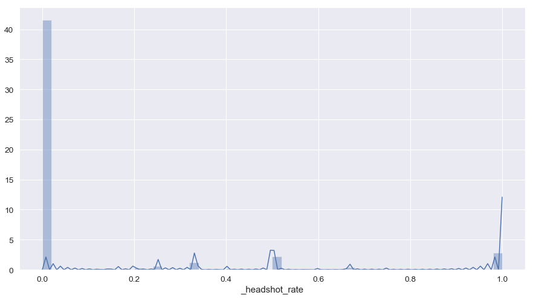

```python
# 100% Headshot Kills
show_distplot('_headshot_rate')
```

```python
# List of Hitman who made more than 10 kills and all the kills were done by headshot(perfect kill)
display(train[(train['_headshot_rate'] == 1) & (train['kills'] >=10)].shape)
train[(train['_headshot_rate'] == 1) & (train['kills'] >= 10)].head(10)
```

```
(24, 31)
```

|  | Id | groupId | matchId | assists | boosts | damageDealt | DBNOs | headshotKills | heals | killPlace | ... | roadKills | swimDistance | teamKills | vehicleDestroys | walkDistance | weaponsAcquired | winPoints | winPlacePerc | _totalDistance | _headshot_rate |
| --- | --- | --- | --- | --- | --- | --- | --- | --- | --- | --- | --- | --- | --- | --- | --- | --- | --- | --- | --- | --- | --- |
| 281570 | ab9d7168570927 | add05ebde0214c | e016a873339c7b | 2 | 3 | 1212.0 | 8 | 10 | 0 | 1 | ... | 0 | 0.000000 | 0 | 0 | 2939.0 | 5 | 0 | 0.8462 | 2939.000000 | 1.0 |
| 346124 | 044d18fc42fc75 | fc1dbc2df6a887 | 628107d4c41084 | 3 | 5 | 1620.0 | 13 | 11 | 3 | 1 | ... | 0 | 0.000000 | 0 | 0 | 3422.0 | 8 | 1560 | 1.0000 | 8142.000000 | 1.0 |
| 871244 | e668a25f5488e3 | 5ba8feabfb2a23 | f6e6581e03ba4f | 0 | 4 | 1365.0 | 9 | 13 | 0 | 1 | ... | 0 | 0.000000 | 0 | 0 | 2105.0 | 5 | 1587 | 1.0000 | 2105.000000 | 1.0 |
| 908815 | 566d8218b705aa | a9b056478d71b2 | 3a41552d553583 | 2 | 5 | 1535.0 | 10 | 10 | 3 | 1 | ... | 0 | 0.000000 | 2 | 0 | 2761.0 | 7 | 1519 | 0.9630 | 7948.000000 | 1.0 |
| 963463 | 1bd6fd288df4f0 | 90584ffa22fe15 | ba2de992ec7bb8 | 2 | 6 | 1355.0 | 12 | 10 | 2 | 1 | ... | 0 | 0.000000 | 0 | 0 | 2458.0 | 4 | 1562 | 1.0000 | 3476.000000 | 1.0 |
| 1079403 | 1c245ed99b5f96 | e42d09a9b8463a | 5cec236bce68eb | 0 | 5 | 1218.0 | 8 | 11 | 3 | 1 | ... | 0 | 0.000000 | 0 | 0 | 2932.0 | 4 | 0 | 1.0000 | 8178.000000 | 1.0 |
| 1167959 | c4f80d4be5c561 | b4a7892189b5dd | c7f7733ebbd447 | 0 | 4 | 1065.0 | 6 | 10 | 1 | 1 | ... | 0 | 0.000000 | 0 | 0 | 2450.0 | 7 | 1468 | 1.0000 | 2858.899902 | 1.0 |
| 1348164 | 474a641f0a4bcb | 2fdad3ca6fb3c0 | 114499c82f35d7 | 1 | 5 | 1319.0 | 11 | 12 | 1 | 1 | ... | 0 | 0.000000 | 0 | 0 | 3915.0 | 5 | 0 | 1.0000 | 5963.000000 | 1.0 |
| 1380385 | 202ce6a55119c5 | 2df66861f597b4 | 496700c29a5d44 | 1 | 4 | 1150.0 | 4 | 11 | 1 | 1 | ... | 0 | 0.000000 | 0 | 0 | 3108.0 | 7 | 1500 | 1.0000 | 3108.000000 | 1.0 |
| 1483199 | 9d483f7cbb34d4 | db5867bc814191 | 69495e3c478eb9 | 0 | 10 | 1478.0 | 8 | 13 | 2 | 1 | ... | 0 | 140.800003 | 0 | 0 | 2339.0 | 4 | 0 | 1.0000 | 2479.800049 | 1.0 |

10 rows × 31 columns

#### Identify the Hackers who can making kills without even moving

```python
# Create feature killsWithoutMoving
train['_killsWithoutMoving'] = ((train['kills'] > 0) & (train['_totalDistance'] == 0))
# Check players who kills without moving
display(train[train['_killsWithoutMoving'] == True].shape)
train[train['_killsWithoutMoving'] == True].head(10)
```

```
(1535, 32)
```

|  | Id | groupId | matchId | assists | boosts | damageDealt | DBNOs | headshotKills | heals | killPlace | ... | swimDistance | teamKills | vehicleDestroys | walkDistance | weaponsAcquired | winPoints | winPlacePerc | _totalDistance | _headshot_rate | _killsWithoutMoving |
| --- | --- | --- | --- | --- | --- | --- | --- | --- | --- | --- | --- | --- | --- | --- | --- | --- | --- | --- | --- | --- | --- |
| 1824 | b538d514ef2476 | 0eb2ce2f43f9d6 | 35e7d750e442e2 | 0 | 0 | 593.000000 | 0 | 0 | 3 | 18 | ... | 0.0 | 0 | 0 | 0.0 | 8 | 0 | 0.8571 | 0.0 | 0.000000 | True |
| 6673 | 6d3a61da07b7cb | 2d8119b1544f87 | 904cecf36217df | 2 | 0 | 346.600006 | 0 | 0 | 6 | 33 | ... | 0.0 | 0 | 0 | 0.0 | 22 | 0 | 0.6000 | 0.0 | 0.000000 | True |
| 11892 | 550398a8f33db7 | c3fd0e2abab0af | db6f6d1f0d4904 | 2 | 0 | 1750.000000 | 0 | 4 | 5 | 3 | ... | 0.0 | 0 | 0 | 0.0 | 13 | 0 | 0.8947 | 0.0 | 0.200000 | True |
| 14631 | 58d690ee461e9d | ea5b6630b33d67 | dbf34301df5e53 | 0 | 0 | 157.800003 | 0 | 0 | 0 | 69 | ... | 0.0 | 0 | 0 | 0.0 | 7 | 1500 | 0.0000 | 0.0 | 0.000000 | True |
| 15591 | 49b61fc963d632 | 0f5c5f19d9cc21 | 904cecf36217df | 0 | 0 | 100.000000 | 0 | 1 | 0 | 37 | ... | 0.0 | 0 | 0 | 0.0 | 10 | 0 | 0.3000 | 0.0 | 1.000000 | True |
| 20881 | 40871bf43ddac7 | 2cea046b7d1dce | 0600f86f11c6e4 | 0 | 0 | 506.100006 | 4 | 1 | 3 | 7 | ... | 0.0 | 0 | 0 | 0.0 | 8 | 0 | 0.8000 | 0.0 | 0.166667 | True |
| 23298 | b950836d0427da | 1f735b1e00d549 | ad860f4e162bbc | 1 | 0 | 1124.000000 | 0 | 4 | 1 | 7 | ... | 0.0 | 0 | 0 | 0.0 | 8 | 0 | 0.6000 | 0.0 | 0.333333 | True |
| 24640 | aeced11d46de19 | d4009ffa95bb4f | 73f3ed869c9171 | 2 | 0 | 529.900024 | 0 | 2 | 11 | 12 | ... | 0.0 | 0 | 0 | 0.0 | 8 | 0 | 0.8571 | 0.0 | 0.285714 | True |
| 25659 | 6626c4d47cffa0 | ee3fe5c0d917c3 | 341341834b7941 | 0 | 1 | 128.899994 | 0 | 1 | 6 | 53 | ... | 0.0 | 0 | 0 | 0.0 | 12 | 1500 | 0.2857 | 0.0 | 0.500000 | True |
| 30079 | 869331b90bfa3f | 869ea3ad036e53 | fa373e28ff5062 | 0 | 0 | 85.559998 | 0 | 0 | 0 | 46 | ... | 0.0 | 0 | 0 | 0.0 | 4 | 0 | 0.8571 | 0.0 | 0.000000 | True |

10 rows × 32 columns

```python
# Drop kill without moving
train.drop(train[train['_killsWithoutMoving'] == True].index, inplace=True)
```

#### PUBG Players knew that only hackers can shot from a distance of 1Km away

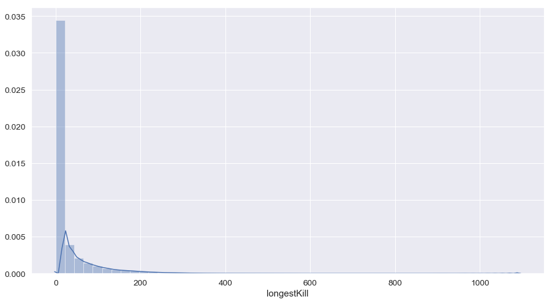

```python
show_distplot('longestKill')
```

```python
train[train['longestKill'] >= 1000]
```

|  | Id | groupId | matchId | assists | boosts | damageDealt | DBNOs | headshotKills | heals | killPlace | ... | swimDistance | teamKills | vehicleDestroys | walkDistance | weaponsAcquired | winPoints | winPlacePerc | _totalDistance | _headshot_rate | _killsWithoutMoving |
| --- | --- | --- | --- | --- | --- | --- | --- | --- | --- | --- | --- | --- | --- | --- | --- | --- | --- | --- | --- | --- | --- |
| 202281 | 88e2af7d78af5a | 34ddeede52c042 | 4346bc63bc67fa | 0 | 3 | 783.900024 | 5 | 1 | 1 | 5 | ... | 0.000000 | 0 | 1 | 3052.000000 | 9 | 0 | 0.9231 | 3775.199951 | 0.250000 | False |
| 240005 | 41c2f5c0699807 | 9faecf87ab4275 | 634edab75860b3 | 5 | 0 | 1284.000000 | 8 | 5 | 7 | 18 | ... | 0.000000 | 0 | 0 | 48.869999 | 38 | 1500 | 0.5385 | 48.869999 | 0.454545 | False |
| 324313 | ef390c152bcc3d | 30fd444be3bbc1 | 4f7f8d6cf558b4 | 2 | 0 | 1028.000000 | 0 | 0 | 0 | 9 | ... | 0.000000 | 0 | 0 | 1264.000000 | 26 | 0 | 1.0000 | 2981.000000 | 0.000000 | False |
| 656553 | 9948b058562163 | c8cb8491112bf6 | 0104eeb664494d | 6 | 0 | 1410.000000 | 17 | 5 | 0 | 3 | ... | 0.000000 | 0 | 0 | 29.209999 | 30 | 1500 | 0.6000 | 29.209999 | 0.312500 | False |
| 803632 | 4e7e6c74e3c57d | 94698690918933 | da91b0c3d875f8 | 0 | 0 | 196.800003 | 0 | 0 | 0 | 51 | ... | 0.000000 | 0 | 0 | 1074.000000 | 22 | 0 | 0.0000 | 3159.000000 | 0.000000 | False |
| 895411 | 1f5ba6e0cfb968 | 512ea24b831be3 | 5fb0d8b1fc16cf | 4 | 0 | 1012.000000 | 11 | 5 | 0 | 5 | ... | 0.000000 | 0 | 0 | 569.500000 | 18 | 0 | 0.9091 | 569.500000 | 0.500000 | False |
| 1172437 | 303a93cfa1f46c | 8795d39fd0df86 | 9c8962b58bb3e3 | 2 | 1 | 329.299988 | 0 | 0 | 2 | 45 | ... | 0.000000 | 0 | 0 | 832.500000 | 9 | 1500 | 0.2857 | 832.500000 | 0.000000 | False |
| 1209416 | 528659ff1c1aec | 7d1ba83423551d | ea9386587d5888 | 0 | 6 | 1640.000000 | 0 | 7 | 0 | 1 | ... | 0.000000 | 0 | 0 | 2848.000000 | 4 | 1500 | 0.9412 | 2848.000000 | 0.466667 | False |
| 1642712 | 91966848e08e2f | 0ee4fbd27657c9 | 17dea22cefe62a | 3 | 2 | 2103.000000 | 0 | 4 | 11 | 11 | ... | 0.000000 | 0 | 0 | 235.300003 | 41 | 0 | 0.5000 | 235.300003 | 0.173913 | False |
| 2015559 | 5ff0c1a9fab2ba | 2d8119b1544f87 | 904cecf36217df | 3 | 3 | 1302.000000 | 0 | 6 | 5 | 15 | ... | 0.000000 | 0 | 0 | 133.199997 | 43 | 0 | 0.6000 | 133.199997 | 0.545455 | False |
| 2122128 | 42df3102cb540b | 7d9b2be15b355b | 610d78f3affd2e | 5 | 0 | 2500.000000 | 0 | 7 | 1 | 2 | ... | 0.000000 | 2 | 0 | 464.500000 | 52 | 0 | 0.0000 | 464.500000 | 0.318182 | False |
| 2152425 | 4b9f61bac5eb0a | bc717b964f3bbe | 838cb9a3c94598 | 3 | 0 | 945.400024 | 0 | 0 | 0 | 11 | ... | 0.000000 | 0 | 0 | 844.700012 | 14 | 0 | 0.5714 | 844.700012 | 0.000000 | False |
| 2592718 | 24e0fec84c18e9 | 8404855ca02e48 | e886a8ebb702cf | 7 | 0 | 1684.000000 | 0 | 4 | 7 | 11 | ... | 0.000000 | 0 | 0 | 1115.000000 | 54 | 1500 | 0.5714 | 4851.000000 | 0.307692 | False |
| 2981715 | 7f77051c7cef52 | d6579a630399b5 | 4784f7d9a06b51 | 3 | 5 | 1025.000000 | 5 | 2 | 5 | 2 | ... | 87.959999 | 0 | 0 | 3998.000000 | 7 | 0 | 1.0000 | 4085.959961 | 0.333333 | False |
| 3081503 | f19a76e8d7ac52 | 624d65c529f87c | de19b70121c40f | 3 | 0 | 1038.000000 | 0 | 0 | 0 | 32 | ... | 0.000000 | 0 | 0 | 270.000000 | 28 | 1500 | 0.8571 | 270.000000 | 0.000000 | False |
| 3255171 | 5524c154448425 | 674195558ad41b | db6f6d1f0d4904 | 1 | 0 | 1355.000000 | 0 | 2 | 0 | 9 | ... | 0.000000 | 1 | 0 | 1039.000000 | 37 | 0 | 0.5789 | 1039.000000 | 0.142857 | False |
| 3304284 | d0c286ce498e17 | 17fdd45e612bab | 3eaaa2f7a360fe | 7 | 0 | 2330.000000 | 0 | 2 | 0 | 2 | ... | 0.000000 | 1 | 0 | 68.019997 | 32 | 0 | 1.0000 | 68.019997 | 0.100000 | False |
| 3320960 | 0040e53dfe7b5d | 650661c2351eb7 | 2daabf3a7852e6 | 0 | 0 | 399.000000 | 2 | 0 | 6 | 14 | ... | 0.000000 | 0 | 0 | 1511.000000 | 45 | 1500 | 0.0000 | 5481.000000 | 0.000000 | False |
| 3552532 | db638834c62f6f | 0614b611d6a935 | ff80300f8262f5 | 2 | 0 | 517.000000 | 0 | 0 | 0 | 10 | ... | 0.000000 | 2 | 0 | 1310.000000 | 6 | 0 | 0.0000 | 1344.880005 | 0.000000 | False |
| 4332473 | d8857d3d7e31b6 | 085de7a36897e6 | 42f997c16d8a0e | 5 | 0 | 1685.000000 | 11 | 3 | 18 | 8 | ... | 0.000000 | 0 | 0 | 523.299988 | 35 | 1500 | 0.9091 | 523.299988 | 0.187500 | False |

20 rows × 32 columns

```python
# Drop longestKill
train.drop(train[train['longestKill'] >= 1000].index, inplace=True)
```

```python
# Players who got more than 10 roadKills
train[train['roadKills'] > 10]
```

|  | Id | groupId | matchId | assists | boosts | damageDealt | DBNOs | headshotKills | heals | killPlace | ... | swimDistance | teamKills | vehicleDestroys | walkDistance | weaponsAcquired | winPoints | winPlacePerc | _totalDistance | _headshot_rate | _killsWithoutMoving |
| --- | --- | --- | --- | --- | --- | --- | --- | --- | --- | --- | --- | --- | --- | --- | --- | --- | --- | --- | --- | --- | --- |
| 2733926 | c3e444f7d1289f | 489dd6d1f2b3bb | 4797482205aaa4 | 0 | 0 | 1246.0 | 0 | 0 | 0 | 1 | ... | 5.297 | 0 | 0 | 1277.000000 | 0 | 1371 | 0.4286 | 1282.302002 | 0.000000 | False |
| 2767999 | 34193085975338 | bd7d50fa305700 | a22354d036b3d6 | 0 | 0 | 1102.0 | 0 | 0 | 0 | 1 | ... | 0.000 | 0 | 0 | 816.599976 | 5 | 1533 | 0.4713 | 4934.600098 | 0.000000 | False |
| 2890740 | a3438934e3e535 | 1081c315a80d14 | fe744430ac0070 | 0 | 8 | 2074.0 | 0 | 1 | 11 | 1 | ... | 0.000 | 0 | 0 | 3150.000000 | 4 | 1568 | 1.0000 | 5876.000000 | 0.050000 | False |
| 3524413 | 9d9d044f81de72 | 8be97e1ba792e3 | 859e2c2db5b125 | 0 | 3 | 1866.0 | 0 | 5 | 7 | 1 | ... | 0.000 | 0 | 0 | 1041.000000 | 10 | 1606 | 0.9398 | 7853.000000 | 0.277778 | False |

4 rows × 32 columns

```python
# Drop roadKill
train.drop(train[train['roadKills'] > 10].index, inplace=True)
```

### Anomalies in travelling

[figure not shown]

```python
train[['walkDistance', 'rideDistance', 'swimDistance']].describe()
```

|  | walkDistance | rideDistance | swimDistance |
| --- | --- | --- | --- |
| count | 4.445397e+06 | 4.445397e+06 | 4.445397e+06 |
| mean | 1.148915e+03 | 6.063006e+02 | 4.510810e+00 |
| std | 1.180580e+03 | 1.496635e+03 | 3.024294e+01 |
| min | 0.000000e+00 | 0.000000e+00 | 0.000000e+00 |
| 25% | 1.554000e+02 | 0.000000e+00 | 0.000000e+00 |
| 50% | 6.863000e+02 | 0.000000e+00 | 0.000000e+00 |
| 75% | 1.977000e+03 | 2.609000e-01 | 0.000000e+00 |
| max | 2.578000e+04 | 4.071000e+04 | 3.823000e+03 |

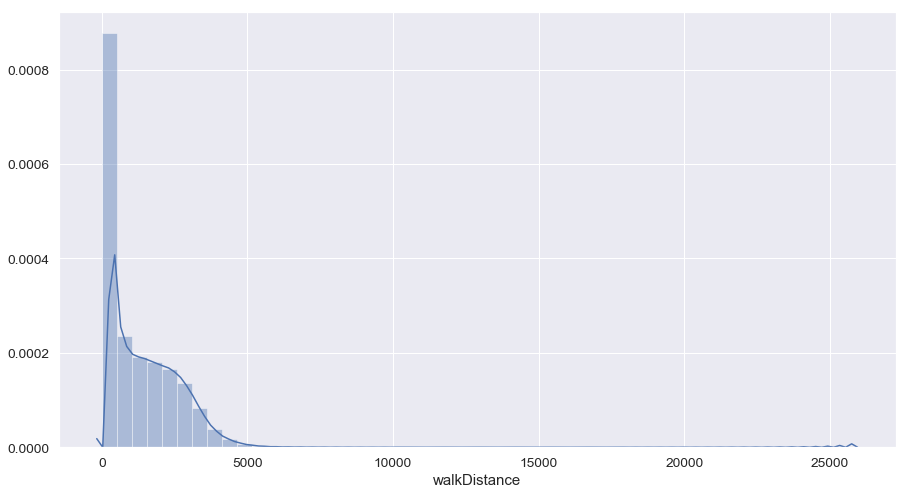

```python
show_distplot('walkDistance')
```

```python
# How they travel 13km with 0 kills!!
train[(train['walkDistance'] >= 13000) & (train['kills'] == 0)]
```

|  | Id | groupId | matchId | assists | boosts | damageDealt | DBNOs | headshotKills | heals | killPlace | ... | swimDistance | teamKills | vehicleDestroys | walkDistance | weaponsAcquired | winPoints | winPlacePerc | _totalDistance | _headshot_rate | _killsWithoutMoving |
| --- | --- | --- | --- | --- | --- | --- | --- | --- | --- | --- | --- | --- | --- | --- | --- | --- | --- | --- | --- | --- | --- |
| 23026 | 8a6562381dd83f | 23e638cd6eaf77 | b0a804a610e9b0 | 0 | 1 | 0.000000 | 0 | 0 | 0 | 44 | ... | 9.882000 | 0 | 0 | 13530.0 | 7 | 0 | 0.8163 | 13540.302734 | 0.0 | False |
| 497965 | 3304d0c68e27f5 | 503757159d22dd | ce88f9c8c35bdf | 0 | 0 | 0.000000 | 0 | 0 | 0 | 46 | ... | 381.899994 | 0 | 0 | 25780.0 | 0 | 0 | 0.9894 | 26161.908203 | 0.0 | False |
| 1072113 | 692e7657b6e340 | 10baa5ce3cdffe | ad7403ad4d20a9 | 0 | 1 | 0.000000 | 0 | 0 | 5 | 50 | ... | 15.270000 | 1 | 0 | 13040.0 | 4 | 0 | 0.6786 | 13055.289062 | 0.0 | False |
| 1137979 | 3c23cf6c61171f | 90b6aaaa2a16b7 | a52c5ac7c18311 | 0 | 2 | 0.000000 | 0 | 0 | 27 | 41 | ... | 80.339996 | 0 | 0 | 13160.0 | 3 | 0 | 0.9643 | 13240.394531 | 0.0 | False |
| 1188935 | 2dd8f83eb3bd7f | d1e7809ff69bb4 | c8585bc8a88aa6 | 0 | 0 | 0.000000 | 0 | 0 | 0 | 44 | ... | 180.699997 | 0 | 0 | 13360.0 | 4 | 0 | 0.9643 | 14798.700195 | 0.0 | False |
| 1797162 | 7b9a750b17e9c6 | 2d00192e4029c5 | 6fe77402ddb0e1 | 0 | 0 | 0.000000 | 0 | 0 | 0 | 55 | ... | 129.399994 | 0 | 0 | 16250.0 | 3 | 0 | 0.6000 | 16379.440430 | 0.0 | False |
| 2078996 | 1284474083cc33 | fa7e10443cc7df | c62835e88e61a6 | 0 | 2 | 0.000000 | 0 | 0 | 3 | 48 | ... | 256.899994 | 0 | 0 | 14250.0 | 8 | 0 | 0.8000 | 15354.600586 | 0.0 | False |
| 2238900 | 861d1e5a63f3e6 | 1da6a90addf96d | 16f2c51578f323 | 0 | 1 | 0.000000 | 0 | 0 | 5 | 46 | ... | 389.500000 | 0 | 0 | 15370.0 | 7 | 0 | 0.8125 | 15759.510742 | 0.0 | False |
| 2990339 | fc3fdd39dcd266 | f901321bc27871 | c0ebfb404aaa47 | 0 | 4 | 75.349998 | 0 | 0 | 0 | 40 | ... | 42.189999 | 0 | 0 | 13070.0 | 4 | 0 | 0.9286 | 14902.190430 | 0.0 | False |
| 3318429 | 25a548c95fa48f | 978df298b094ba | 99407bcde7569c | 0 | 0 | 0.000000 | 0 | 0 | 2 | 39 | ... | 38.439999 | 0 | 0 | 13660.0 | 1 | 0 | 0.8913 | 13698.454102 | 0.0 | False |
| 3825937 | 40f2b3bf019c5d | e24f1dd132c42a | 899f4f3b994091 | 0 | 1 | 40.070000 | 0 | 0 | 2 | 41 | ... | 68.169998 | 0 | 0 | 13500.0 | 3 | 1521 | 0.7308 | 13568.329102 | 0.0 | False |

11 rows × 32 columns

```python
# Drop walking anomalies
train.drop(train[(train['walkDistance'] >= 13000) & (train['kills'] == 0)].index, inplace=True)
```

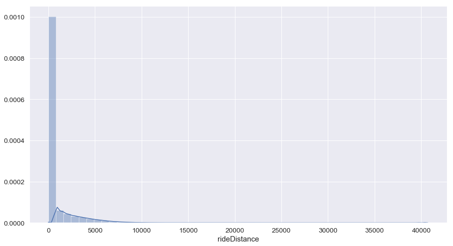

```python
show_distplot('rideDistance')
```

```python
# Wandered Huh! Ofcourse how they travelled 30km without even a single kill! Again Hackers!
train[(train['rideDistance']>=30000) & (train['kills']==0)]
```

|  | Id | groupId | matchId | assists | boosts | damageDealt | DBNOs | headshotKills | heals | killPlace | ... | swimDistance | teamKills | vehicleDestroys | walkDistance | weaponsAcquired | winPoints | winPlacePerc | _totalDistance | _headshot_rate | _killsWithoutMoving |
| --- | --- | --- | --- | --- | --- | --- | --- | --- | --- | --- | --- | --- | --- | --- | --- | --- | --- | --- | --- | --- | --- |
| 426708 | 149e224a2330ae | 6d8cb80b3de8ff | f8b8e2643f60ee | 0 | 2 | 0.000000 | 0 | 0 | 2 | 43 | ... | 0.0 | 0 | 0 | 402.100006 | 3 | 1449 | 0.8171 | 32362.099609 | 0.0 | False |
| 605623 | 8dee54600c67ca | e77f3e175b5959 | 26bc606cdae6bf | 0 | 0 | 11.210000 | 0 | 0 | 0 | 27 | ... | 0.0 | 0 | 0 | 1641.000000 | 0 | 1498 | 0.6800 | 35611.000000 | 0.0 | False |
| 1232362 | 4bf27787223351 | b0140dd17f3238 | 5ed9c405f7e71d | 0 | 1 | 0.000000 | 0 | 0 | 10 | 47 | ... | 0.0 | 1 | 0 | 1473.000000 | 3 | 0 | 0.7979 | 32483.000000 | 0.0 | False |
| 1725337 | 9f14f77b6dd9b6 | 8a2a8ae2506323 | 904b5fa7f59bc5 | 0 | 2 | 2.389000 | 0 | 0 | 5 | 19 | ... | 0.0 | 0 | 0 | 542.099976 | 2 | 1565 | 0.6944 | 38212.101562 | 0.0 | False |
| 2137063 | 73b793b4e7523f | f4444641af7e5c | 6385f7641268c3 | 0 | 0 | 0.000000 | 0 | 0 | 0 | 52 | ... | 0.0 | 0 | 0 | 28.760000 | 0 | 0 | 0.7204 | 31398.759766 | 0.0 | False |
| 2700691 | 3428324a089608 | fa77b4ac736dbf | 9b1c87f4016f47 | 0 | 1 | 31.270000 | 0 | 0 | 0 | 46 | ... | 0.0 | 0 | 0 | 174.100006 | 1 | 1530 | 0.8557 | 31464.099609 | 0.0 | False |
| 2927408 | 260efc0cf6b36c | b112f8d21e8185 | 3e977510ce1d3c | 0 | 0 | 11.220000 | 0 | 0 | 0 | 44 | ... | 0.0 | 0 | 0 | 426.600006 | 2 | 1619 | 0.8132 | 31086.599609 | 0.0 | False |
| 3404578 | 8e84f4228e5436 | c5ca5892142cbd | 56775920f704e8 | 0 | 0 | 3.298000 | 0 | 0 | 0 | 40 | ... | 0.0 | 0 | 0 | 233.699997 | 5 | 1497 | 0.9175 | 32553.699219 | 0.0 | False |
| 3567265 | 99f342c6022411 | 9158efebffecc7 | ddbe41fe165c7f | 2 | 2 | 113.199997 | 0 | 0 | 3 | 34 | ... | 0.0 | 0 | 0 | 616.200012 | 4 | 0 | 1.0000 | 31636.199219 | 0.0 | False |
| 4099938 | afe34618b04d77 | c14f532b283844 | 732c3b752e055f | 0 | 0 | 0.000000 | 0 | 0 | 0 | 42 | ... | 0.0 | 0 | 0 | 560.099976 | 0 | 0 | 0.8478 | 41270.101562 | 0.0 | False |
| 4150057 | a74c1acff09c4f | a1488a2d301bc4 | 98f74c2a19a67e | 0 | 0 | 18.760000 | 0 | 0 | 0 | 51 | ... | 0.0 | 0 | 0 | 27.299999 | 0 | 1505 | 0.6392 | 30137.300781 | 0.0 | False |
| 4440261 | 9a7c448670f199 | 04b0e435abc817 | a4063f40804b24 | 0 | 0 | 0.000000 | 0 | 0 | 0 | 45 | ... | 0.0 | 0 | 0 | 23.770000 | 0 | 0 | 0.7474 | 31713.769531 | 0.0 | False |

12 rows × 32 columns

```python
# How is it even possible that a player is able to ride and kill without walking even a single meter ?
train[(train['walkDistance']==0) & (train['rideDistance']>0) & (train['kills']>0)]
```

|  | Id | groupId | matchId | assists | boosts | damageDealt | DBNOs | headshotKills | heals | killPlace | ... | swimDistance | teamKills | vehicleDestroys | walkDistance | weaponsAcquired | winPoints | winPlacePerc | _totalDistance | _headshot_rate | _killsWithoutMoving |
| --- | --- | --- | --- | --- | --- | --- | --- | --- | --- | --- | --- | --- | --- | --- | --- | --- | --- | --- | --- | --- | --- |
| 219621 | 49e86bcbb74918 | 5bf4ac7f5f89a0 | 05a97d10e3cf81 | 0 | 0 | 100.000000 | 1 | 0 | 0 | 38 | ... | 0.0 | 0 | 0 | 0.0 | 0 | 0 | 0.0000 | 673.099976 | 0.0 | False |
| 1051447 | c43116d1c3d4e5 | bd09c97b67800a | aad60eee7eeb79 | 0 | 0 | 102.199997 | 0 | 0 | 0 | 34 | ... | 0.0 | 0 | 0 | 0.0 | 0 | 1532 | 0.1250 | 1757.000000 | 0.0 | False |
| 1053213 | 4a8011f19b0e0e | 037c89b0cef255 | 238171821a1d0e | 1 | 0 | 100.000000 | 1 | 0 | 0 | 38 | ... | 0.0 | 0 | 0 | 0.0 | 0 | 1747 | 0.0638 | 36.240002 | 0.0 | False |
| 1166930 | 553f199b5538c5 | 560c2ba9dcbbd0 | afb05e37d884fc | 2 | 0 | 168.500000 | 1 | 0 | 0 | 45 | ... | 0.0 | 0 | 0 | 0.0 | 0 | 1499 | 0.0667 | 391.799988 | 0.0 | False |
| 1479750 | bcdf0f6c5d08bf | ea2ed2cc5955dd | 2b59ed013eaf15 | 0 | 0 | 100.000000 | 1 | 0 | 0 | 46 | ... | 0.0 | 0 | 0 | 0.0 | 0 | 0 | 0.0612 | 468.299988 | 0.0 | False |
| 2221273 | a280df87d394fc | 61042f8c96538c | a0e8fe0599288c | 0 | 0 | 100.000000 | 1 | 0 | 0 | 37 | ... | 0.0 | 0 | 0 | 0.0 | 0 | 0 | 0.1522 | 534.500000 | 0.0 | False |
| 2382410 | adbda59d2f11cd | 343d453ffb18c8 | cbb5f864c6f532 | 0 | 0 | 100.000000 | 1 | 0 | 0 | 43 | ... | 0.0 | 0 | 0 | 0.0 | 0 | 0 | 0.0000 | 262.700012 | 0.0 | False |
| 2471705 | b968373063f5a8 | 536e9c19659ce8 | 61c90034dc8174 | 0 | 0 | 93.470001 | 1 | 0 | 0 | 38 | ... | 0.0 | 0 | 0 | 0.0 | 0 | 0 | 0.1429 | 1360.000000 | 0.0 | False |
| 2907639 | 2bf1d34142358b | 71c15011651348 | 08dfa30b9390f7 | 4 | 0 | 578.000000 | 0 | 0 | 6 | 30 | ... | 0.0 | 0 | 0 | 0.0 | 29 | 0 | 0.4000 | 1277.000000 | 0.0 | False |
| 3778837 | ca3ca72549b07f | 68a0c84f3b09aa | f72f06cafb3349 | 0 | 0 | 144.300003 | 2 | 0 | 0 | 20 | ... | 0.0 | 0 | 0 | 0.0 | 0 | 1496 | 0.0000 | 415.399994 | 0.0 | False |
| 3878026 | 98b29b9a3c1d2d | 5367c310b33253 | 32b26ac193c9ee | 0 | 0 | 100.000000 | 1 | 0 | 0 | 43 | ... | 0.0 | 0 | 0 | 0.0 | 0 | 0 | 0.0208 | 82.080002 | 0.0 | False |
| 4223250 | 5e7e5c37b5bfaa | 4b8e96fa341568 | 73cb1c5f2685f3 | 0 | 0 | 100.000000 | 1 | 0 | 0 | 40 | ... | 0.0 | 0 | 0 | 0.0 | 0 | 0 | 0.0000 | 543.500000 | 0.0 | False |
| 4261511 | 5151e02af2b0ef | ab966381a28eac | 560ec48b1f3371 | 0 | 0 | 272.799988 | 0 | 0 | 0 | 19 | ... | 0.0 | 0 | 0 | 0.0 | 0 | 0 | 0.0879 | 226.399994 | 0.0 | False |

13 rows × 32 columns

```python
# What a player is doing with out even covered a single meter!! HUH!!
train[train['_totalDistance']==0]
```

|  | Id | groupId | matchId | assists | boosts | damageDealt | DBNOs | headshotKills | heals | killPlace | ... | swimDistance | teamKills | vehicleDestroys | walkDistance | weaponsAcquired | winPoints | winPlacePerc | _totalDistance | _headshot_rate | _killsWithoutMoving |
| --- | --- | --- | --- | --- | --- | --- | --- | --- | --- | --- | --- | --- | --- | --- | --- | --- | --- | --- | --- | --- | --- |
| 29 | ac5b57ff39979c | 857cc55b2b6001 | e019e04dee4f19 | 0 | 0 | 0.000000 | 0 | 0 | 0 | 87 | ... | 0.0 | 0 | 0 | 0.0 | 0 | 0 | 0.0000 | 0.0 | 0.0 | False |
| 116 | 6adb021f5165ff | 58e5500bd40898 | de5c692fe25a73 | 0 | 0 | 0.000000 | 0 | 0 | 0 | 68 | ... | 0.0 | 0 | 0 | 0.0 | 0 | 847 | 0.0000 | 0.0 | 0.0 | False |
| 151 | a2bbe20aa8789d | 926e8a09bab249 | e36e4203ed4831 | 0 | 0 | 0.000000 | 0 | 0 | 0 | 92 | ... | 0.0 | 0 | 0 | 0.0 | 0 | 765 | 0.0000 | 0.0 | 0.0 | False |
| 237 | baaa694658e085 | d034728f22cff7 | fa71620624d3e7 | 0 | 0 | 0.000000 | 0 | 0 | 0 | 94 | ... | 0.0 | 0 | 0 | 0.0 | 0 | 1510 | 0.0000 | 0.0 | 0.0 | False |
| 283 | 3ab8128e6bcbe6 | bb52a209f2e938 | aabd2650b129e2 | 0 | 0 | 0.000000 | 0 | 0 | 0 | 84 | ... | 0.0 | 0 | 0 | 0.0 | 0 | 0 | 0.1277 | 0.0 | 0.0 | False |
| 404 | ab33fe5e5c9fb8 | a9a82e992fb212 | 3122bae9aa21f7 | 0 | 0 | 0.000000 | 0 | 0 | 0 | 90 | ... | 0.0 | 0 | 0 | 0.0 | 0 | 0 | 0.0000 | 0.0 | 0.0 | False |
| 520 | 5c654ee06cb3e5 | 2b3a65fd9039d9 | 99407bcde7569c | 0 | 0 | 0.000000 | 0 | 0 | 0 | 91 | ... | 0.0 | 0 | 0 | 0.0 | 0 | 0 | 0.0000 | 0.0 | 0.0 | False |
| 606 | ae1a75a25368a7 | 1802036181a177 | 4aba049c347429 | 0 | 0 | 0.000000 | 0 | 0 | 0 | 94 | ... | 0.0 | 0 | 0 | 0.0 | 0 | 0 | 0.0000 | 0.0 | 0.0 | False |
| 619 | 30131ea60bc193 | 12332138d02c6b | df5f61d4578df0 | 0 | 0 | 0.000000 | 0 | 0 | 0 | 90 | ... | 0.0 | 0 | 0 | 0.0 | 0 | 0 | 0.0000 | 0.0 | 0.0 | False |
| 638 | 604d3aa575de95 | 716c7e34c44f21 | 3b8b7b63decaf5 | 0 | 0 | 0.000000 | 0 | 0 | 0 | 90 | ... | 0.0 | 0 | 0 | 0.0 | 0 | 1504 | 0.0000 | 0.0 | 0.0 | False |
| 666 | 6cfc8f0eaf62ef | 3aa296b41e7d84 | 964e413d5b40ee | 0 | 0 | 0.000000 | 0 | 0 | 0 | 93 | ... | 0.0 | 0 | 0 | 0.0 | 0 | 1466 | 0.0000 | 0.0 | 0.0 | False |
| 711 | b9a35e03db6a7f | 7b1b2b23d70cad | e1d2ac9fe9bbe1 | 0 | 0 | 0.000000 | 0 | 0 | 0 | 95 | ... | 0.0 | 0 | 0 | 0.0 | 1 | 0 | 0.0000 | 0.0 | 0.0 | False |
| 714 | 2c60be6162ede1 | c82e27bce4d7eb | 8ec4b2c35644bb | 0 | 0 | 0.000000 | 0 | 0 | 0 | 88 | ... | 0.0 | 0 | 0 | 0.0 | 0 | 0 | 0.0000 | 0.0 | 0.0 | False |
| 846 | 0df7c355497d77 | 325464bcf4c846 | f3a64f99badeca | 0 | 0 | 0.000000 | 0 | 0 | 0 | 5 | ... | 0.0 | 0 | 0 | 0.0 | 6 | 0 | 0.0000 | 0.0 | 0.0 | False |
| 863 | bc2bdb4111a03f | c3ec76df8da035 | 1a479a1be763c4 | 0 | 0 | 0.000000 | 0 | 0 | 0 | 73 | ... | 0.0 | 0 | 0 | 0.0 | 0 | 1486 | 0.2174 | 0.0 | 0.0 | False |
| 1123 | dff53c848b5d98 | a91e364cc20916 | 453e4e905d4718 | 0 | 0 | 0.000000 | 0 | 0 | 0 | 92 | ... | 0.0 | 0 | 0 | 0.0 | 0 | 1422 | 0.0000 | 0.0 | 0.0 | False |
| 1237 | 5d55ae35ee2b74 | 504e2c1cb2753c | 662dbf3f817677 | 0 | 0 | 0.000000 | 0 | 0 | 0 | 95 | ... | 0.0 | 0 | 0 | 0.0 | 0 | 1555 | 0.0000 | 0.0 | 0.0 | False |
| 1261 | ae741aa8632a85 | 64a7a3ba754875 | 92fbfce85b977d | 0 | 0 | 0.000000 | 0 | 0 | 0 | 85 | ... | 0.0 | 0 | 0 | 0.0 | 0 | 708 | 0.0000 | 0.0 | 0.0 | False |
| 1276 | d3c4dd2e585d21 | 6af9bb6b56b722 | 16e6befa897b44 | 0 | 0 | 0.000000 | 0 | 0 | 0 | 88 | ... | 0.0 | 0 | 0 | 0.0 | 0 | 0 | 0.0000 | 0.0 | 0.0 | False |
| 1285 | 10c259001cc7e9 | 953d38b187f67a | 0419c610115e42 | 0 | 0 | 0.000000 | 0 | 0 | 0 | 61 | ... | 0.0 | 0 | 0 | 0.0 | 0 | 1492 | 0.2581 | 0.0 | 0.0 | False |
| 1297 | 1ed96c3885eb4c | 98c97c4e3ce671 | c3be39757801e7 | 0 | 0 | 0.000000 | 0 | 0 | 0 | 87 | ... | 0.0 | 0 | 0 | 0.0 | 0 | 0 | 0.0000 | 0.0 | 0.0 | False |
| 1357 | 72f70c6c074ca9 | da042db555b932 | f3c5fa51aacb95 | 0 | 0 | 722.799988 | 0 | 0 | 0 | 5 | ... | 0.0 | 0 | 0 | 0.0 | 15 | 0 | 0.0000 | 0.0 | 0.0 | False |
| 1402 | a09e457e6548d6 | 5dd8e600f0bd23 | bf137e4ea666dc | 0 | 0 | 0.000000 | 0 | 0 | 0 | 90 | ... | 0.0 | 0 | 0 | 0.0 | 0 | 0 | 0.0385 | 0.0 | 0.0 | False |
| 1407 | 8758a2435e830d | 1af79186b7496d | 18d74c805fbb67 | 0 | 0 | 0.000000 | 0 | 0 | 0 | 74 | ... | 0.0 | 0 | 0 | 0.0 | 0 | 1597 | 0.3125 | 0.0 | 0.0 | False |
| 1416 | 4c5cee593b598c | e6a576f52d9af7 | ee5f91e48ef31c | 0 | 0 | 0.000000 | 0 | 0 | 0 | 95 | ... | 0.0 | 0 | 0 | 0.0 | 0 | 0 | 0.0000 | 0.0 | 0.0 | False |
| 1433 | 0a5036716cd6e0 | 65d3de7c9396c4 | 75cbdf89be0139 | 0 | 0 | 85.599998 | 0 | 0 | 0 | 90 | ... | 0.0 | 0 | 0 | 0.0 | 1 | 0 | 0.0000 | 0.0 | 0.0 | False |
| 1466 | 1cdc3ccbd2d74d | 0fdecd76073ad2 | 91731eb734dae5 | 0 | 0 | 0.000000 | 0 | 0 | 0 | 90 | ... | 0.0 | 0 | 0 | 0.0 | 0 | 0 | 0.0425 | 0.0 | 0.0 | False |
| 1475 | 1296e1acf0eea2 | fd2b3948654213 | 8cc67fbee871d4 | 0 | 0 | 0.000000 | 0 | 0 | 0 | 96 | ... | 0.0 | 0 | 0 | 0.0 | 0 | 0 | 0.0000 | 0.0 | 0.0 | False |
| 1490 | 287bf9cb676611 | 32660841e1b848 | 4c576b9fcef0f6 | 0 | 0 | 0.000000 | 0 | 0 | 0 | 81 | ... | 0.0 | 0 | 0 | 0.0 | 0 | 0 | 0.0000 | 0.0 | 0.0 | False |
| 1523 | 2c8b87feacd185 | 02974d2b816985 | 0632de69b7a2bd | 0 | 0 | 0.000000 | 0 | 0 | 0 | 92 | ... | 0.0 | 0 | 0 | 0.0 | 0 | 0 | 0.0000 | 0.0 | 0.0 | False |
| ... | ... | ... | ... | ... | ... | ... | ... | ... | ... | ... | ... | ... | ... | ... | ... | ... | ... | ... | ... | ... | ... |
| 4446157 | e025dfecd57bc2 | ca46af5547eae4 | f3bd832f07f17e | 0 | 0 | 0.000000 | 0 | 0 | 0 | 95 | ... | 0.0 | 0 | 0 | 0.0 | 1 | 0 | 0.0000 | 0.0 | 0.0 | False |
| 4446175 | 9f5d6a6fdb8110 | 1b4f590559562a | 8098689f9e8536 | 0 | 0 | 0.000000 | 0 | 0 | 0 | 95 | ... | 0.0 | 0 | 0 | 0.0 | 0 | 1517 | 0.0000 | 0.0 | 0.0 | False |
| 4446255 | 3d8f33beb08bf9 | 3e20b1eef81a88 | 2ce58b088804fc | 0 | 0 | 0.000000 | 0 | 0 | 0 | 91 | ... | 0.0 | 0 | 0 | 0.0 | 0 | 0 | 0.0000 | 0.0 | 0.0 | False |
| 4446292 | 3d6b71161766ac | b3763553a755c0 | 598108e4079546 | 0 | 0 | 0.000000 | 0 | 0 | 0 | 96 | ... | 0.0 | 0 | 0 | 0.0 | 0 | 1454 | 0.0000 | 0.0 | 0.0 | False |
| 4446312 | c7146b42f095c8 | 9b146258d6ae7d | 9dfc737185ea9a | 0 | 0 | 0.000000 | 0 | 0 | 0 | 91 | ... | 0.0 | 0 | 0 | 0.0 | 0 | 0 | 0.0000 | 0.0 | 0.0 | False |
| 4446318 | 13ca7294094cfb | 0e120a8d2f6105 | 07baf6b1ba3de9 | 0 | 0 | 0.000000 | 0 | 0 | 0 | 1 | ... | 0.0 | 0 | 0 | 0.0 | 21 | 0 | 0.0000 | 0.0 | 0.0 | False |
| 4446340 | 61f1378ff86fd0 | 4fc1816efb9b02 | 20b536a42eb602 | 0 | 0 | 0.000000 | 0 | 0 | 0 | 92 | ... | 0.0 | 0 | 0 | 0.0 | 0 | 0 | 0.0000 | 0.0 | 0.0 | False |
| 4446347 | 8c1d4279befead | f88809fc2299e7 | f76312fd6ab0e0 | 0 | 0 | 0.000000 | 0 | 0 | 0 | 89 | ... | 0.0 | 0 | 0 | 0.0 | 0 | 0 | 0.0000 | 0.0 | 0.0 | False |
| 4446397 | dcfc009e03dc1c | 78e19674b02d1b | cd4a0962438bbc | 0 | 0 | 0.000000 | 0 | 0 | 0 | 92 | ... | 0.0 | 0 | 0 | 0.0 | 0 | 0 | 0.0000 | 0.0 | 0.0 | False |
| 4446409 | e3fb79003bcb86 | 21b03330927c78 | 9b08b61379b1a3 | 0 | 0 | 0.000000 | 0 | 0 | 0 | 96 | ... | 0.0 | 0 | 0 | 0.0 | 0 | 0 | 0.0000 | 0.0 | 0.0 | False |
| 4446411 | 8a5f2360412eff | f093b2d3fafd18 | f3fb18b6a91eb4 | 0 | 0 | 0.000000 | 0 | 0 | 0 | 84 | ... | 0.0 | 0 | 0 | 0.0 | 0 | 718 | 0.0000 | 0.0 | 0.0 | False |
| 4446427 | 28a9b78c54f158 | fd83be43b02736 | 74d78cb420efdd | 0 | 0 | 0.000000 | 0 | 0 | 0 | 86 | ... | 0.0 | 0 | 0 | 0.0 | 0 | 615 | 0.0000 | 0.0 | 0.0 | False |
| 4446448 | c8b66adbc2a197 | 9a3acd238bbc5e | fa0185c57626dc | 0 | 0 | 0.000000 | 0 | 0 | 0 | 91 | ... | 0.0 | 0 | 0 | 0.0 | 0 | 0 | 0.0000 | 0.0 | 0.0 | False |
| 4446464 | 672a8673146c3e | 910ef021cfa4ee | 7d66e01d3d9cd5 | 0 | 0 | 0.000000 | 0 | 0 | 0 | 91 | ... | 0.0 | 0 | 0 | 0.0 | 1 | 0 | 0.0532 | 0.0 | 0.0 | False |
| 4446544 | 161b814b3418ad | 24e32d06e17c6f | 3db663307a4543 | 0 | 0 | 0.000000 | 0 | 0 | 0 | 94 | ... | 0.0 | 0 | 0 | 0.0 | 0 | 1445 | 0.0000 | 0.0 | 0.0 | False |
| 4446551 | 60497fc44a0b23 | b1fa1e3a31182f | a329ac99449ad7 | 0 | 0 | 0.000000 | 0 | 0 | 0 | 95 | ... | 0.0 | 0 | 0 | 0.0 | 0 | 1656 | 0.0000 | 0.0 | 0.0 | False |
| 4446574 | 8d352a64869a55 | bc570c0e802930 | 58f30b7f002ecc | 0 | 0 | 0.000000 | 0 | 0 | 0 | 87 | ... | 0.0 | 0 | 0 | 0.0 | 0 | 0 | 0.0000 | 0.0 | 0.0 | False |
| 4446585 | 0000994ff41f46 | 6ff9e9ee9513c5 | 5d65bd2700a8dd | 0 | 0 | 0.000000 | 0 | 0 | 0 | 82 | ... | 0.0 | 0 | 0 | 0.0 | 0 | 0 | 0.0652 | 0.0 | 0.0 | False |
| 4446592 | a24090a1f3b60c | 64e51e49c855ec | 7d26eea334454b | 0 | 0 | 0.000000 | 0 | 0 | 0 | 81 | ... | 0.0 | 0 | 0 | 0.0 | 0 | 0 | 0.0000 | 0.0 | 0.0 | False |
| 4446618 | cebc5a90db2cba | 226314a3f5c5d4 | d65af89f6107c5 | 0 | 0 | 0.000000 | 0 | 0 | 0 | 95 | ... | 0.0 | 0 | 0 | 0.0 | 0 | 0 | 0.0000 | 0.0 | 0.0 | False |
| 4446650 | bfdfca87119de6 | e99e69e166cfa1 | b64972818b6a6e | 0 | 0 | 0.000000 | 0 | 0 | 0 | 92 | ... | 0.0 | 0 | 0 | 0.0 | 0 | 0 | 0.0000 | 0.0 | 0.0 | False |
| 4446743 | 5603233f6b7cf6 | 1896f69a5f7fc0 | 18d34e5142839f | 0 | 0 | 0.000000 | 0 | 0 | 0 | 85 | ... | 0.0 | 0 | 0 | 0.0 | 0 | 0 | 0.0000 | 0.0 | 0.0 | False |
| 4446779 | dec9a10a058c9c | 3c66fb620b3631 | a83fe9ee429644 | 0 | 0 | 0.000000 | 0 | 0 | 0 | 85 | ... | 0.0 | 0 | 0 | 0.0 | 0 | 532 | 0.0000 | 0.0 | 0.0 | False |
| 4446786 | 12c053c0567dca | 9db52b9e2d4f8c | fe0c3ccbea8181 | 0 | 0 | 0.000000 | 0 | 0 | 0 | 84 | ... | 0.0 | 0 | 0 | 0.0 | 1 | 0 | 0.0000 | 0.0 | 0.0 | False |
| 4446812 | 484990766633ce | 77770865680fe0 | fb5acb99d6dc45 | 0 | 0 | 0.000000 | 0 | 0 | 0 | 95 | ... | 0.0 | 0 | 0 | 0.0 | 1 | 0 | 0.0000 | 0.0 | 0.0 | False |
| 4446843 | 56f1ff8594a328 | 63008ee9676bc3 | b3f07953e112dc | 0 | 0 | 0.000000 | 0 | 0 | 0 | 99 | ... | 0.0 | 0 | 0 | 0.0 | 0 | 0 | 0.0000 | 0.0 | 0.0 | False |
| 4446849 | 19d2b52c9e17a3 | f8a952ce9ab7aa | 2afb2889026133 | 0 | 0 | 0.000000 | 0 | 0 | 0 | 90 | ... | 0.0 | 0 | 0 | 0.0 | 0 | 1363 | 0.0412 | 0.0 | 0.0 | False |
| 4446905 | f93dfebceecc59 | c54ca5bb9df107 | e1da3a1ee799ef | 0 | 0 | 0.000000 | 0 | 0 | 0 | 89 | ... | 0.0 | 0 | 0 | 0.0 | 1 | 0 | 0.0417 | 0.0 | 0.0 | False |
| 4446926 | e0c791ea3c4644 | e18240dcce54f9 | 827639896a20cb | 0 | 0 | 0.000000 | 0 | 0 | 0 | 87 | ... | 0.0 | 0 | 0 | 0.0 | 0 | 916 | 0.0000 | 0.0 | 0.0 | False |
| 4446958 | 837349af7e8a35 | 58bc4104935623 | 2001300d4f5787 | 0 | 0 | 0.000000 | 0 | 0 | 0 | 92 | ... | 0.0 | 0 | 0 | 0.0 | 0 | 0 | 0.0000 | 0.0 | 0.0 | False |

95834 rows × 32 columns

```python
# Drop riding anomalies
train.drop(train[(train['rideDistance'] >= 30000) & (train['kills'] == 0)].index, inplace = True)
train.drop(train[(train['walkDistance'] == 0) & (train['rideDistance'] > 0) & (train['kills'] > 0)].index, inplace = True)
train.drop(train[(train['_totalDistance'] == 0)].index, inplace=True)
```

## Let's Check SwimDistance Hackers!!

### HMM!! Strange a player can't be alilve without breathing in the water but here you found some wierd Anomalies. Let's Drop The HACKERS!!

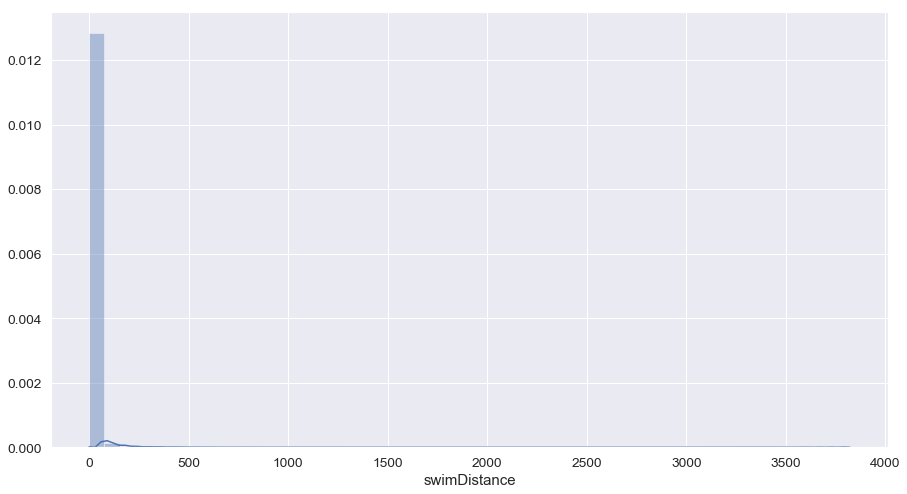

```python
show_distplot('swimDistance')
```

```python
train[train['swimDistance']>=2000]
```

|  | Id | groupId | matchId | assists | boosts | damageDealt | DBNOs | headshotKills | heals | killPlace | ... | swimDistance | teamKills | vehicleDestroys | walkDistance | weaponsAcquired | winPoints | winPlacePerc | _totalDistance | _headshot_rate | _killsWithoutMoving |
| --- | --- | --- | --- | --- | --- | --- | --- | --- | --- | --- | --- | --- | --- | --- | --- | --- | --- | --- | --- | --- | --- |
| 177973 | c2e9e5631f4e54 | 23213058f83abe | f01eb1073ef377 | 0 | 5 | 78.120003 | 1 | 0 | 1 | 47 | ... | 2295.0 | 0 | 0 | 1002.000000 | 4 | 1466 | 0.9592 | 3297.000000 | 0.000000 | False |
| 274258 | ba5e3dfb5a0fa0 | 383db055216ec2 | d6e13468e28ab4 | 0 | 4 | 53.320000 | 0 | 0 | 16 | 39 | ... | 2148.0 | 0 | 0 | 2276.000000 | 5 | 0 | 0.9600 | 10113.000000 | 0.000000 | False |
| 1005337 | d50c9d0e65fe2a | 4996575c11abcb | 668402592429f8 | 0 | 1 | 503.000000 | 4 | 3 | 1 | 6 | ... | 2718.0 | 0 | 0 | 4691.000000 | 5 | 1516 | 1.0000 | 10740.000000 | 1.000000 | False |
| 1195818 | f811de9de80b70 | d08ddf7beb6252 | 8a48703ab52ec8 | 0 | 7 | 352.299988 | 3 | 1 | 6 | 4 | ... | 2668.0 | 0 | 0 | 415.100006 | 10 | 1499 | 1.0000 | 3083.100098 | 0.200000 | False |
| 1227362 | a33e917875c80e | 5b72674b42712b | 5fb0d8b1fc16cf | 0 | 1 | 589.200012 | 3 | 1 | 1 | 46 | ... | 3823.0 | 0 | 0 | 995.299988 | 9 | 0 | 1.0000 | 4818.299805 | 0.500000 | False |
| 1889163 | bd8cc3083a9923 | 1d5d17140d6fa4 | 8e2e6022d6e5c8 | 0 | 0 | 0.000000 | 0 | 0 | 0 | 47 | ... | 2484.0 | 0 | 0 | 1966.000000 | 3 | 0 | 0.5833 | 5314.000000 | 0.000000 | False |
| 2065940 | 312ccbb27b99aa | 47c7f4d69e2fb1 | b4b11756321f3a | 1 | 3 | 49.590000 | 0 | 0 | 5 | 48 | ... | 3514.0 | 0 | 0 | 4296.000000 | 8 | 1492 | 0.8511 | 9899.000000 | 0.000000 | False |
| 2327586 | 8773d0687c6aae | b17f46f9f6666c | 56ee5897512c86 | 3 | 1 | 474.399994 | 2 | 0 | 0 | 7 | ... | 2387.0 | 0 | 0 | 7.546000 | 6 | 0 | 1.0000 | 2394.545898 | 0.000000 | False |
| 2784855 | a8653b87e83892 | 383db055216ec2 | d6e13468e28ab4 | 1 | 4 | 843.799988 | 5 | 5 | 2 | 2 | ... | 2206.0 | 0 | 0 | 4687.000000 | 4 | 0 | 0.9600 | 9926.000000 | 0.714286 | False |
| 3359439 | 3713b36e1ba9e1 | 1f7aed9240864a | 584447ed875c85 | 0 | 0 | 0.000000 | 0 | 0 | 0 | 77 | ... | 2338.0 | 0 | 0 | 1750.000000 | 0 | 1518 | 0.2143 | 4088.000000 | 0.000000 | False |
| 3513522 | aff482b8c08486 | 383db055216ec2 | d6e13468e28ab4 | 0 | 4 | 109.800003 | 0 | 0 | 18 | 40 | ... | 2124.0 | 0 | 0 | 3973.000000 | 5 | 0 | 0.9600 | 9809.000000 | 0.000000 | False |
| 4132225 | 2496e3223a8b5d | 78980ab36f7642 | 23ec7dd5546022 | 0 | 0 | 0.000000 | 0 | 0 | 0 | 83 | ... | 2382.0 | 0 | 0 | 1534.000000 | 0 | 0 | 0.0851 | 3916.000000 | 0.000000 | False |

12 rows × 32 columns

```python
train.drop(train[train['swimDistance']>=2000].index,inplace=True)
```

## Anomalies detection in WeaponAcquired

Most people acquire between 0 and 10 weapons in a game, but you also see some people acquire more than 80 weapons! Let's check these guys out.

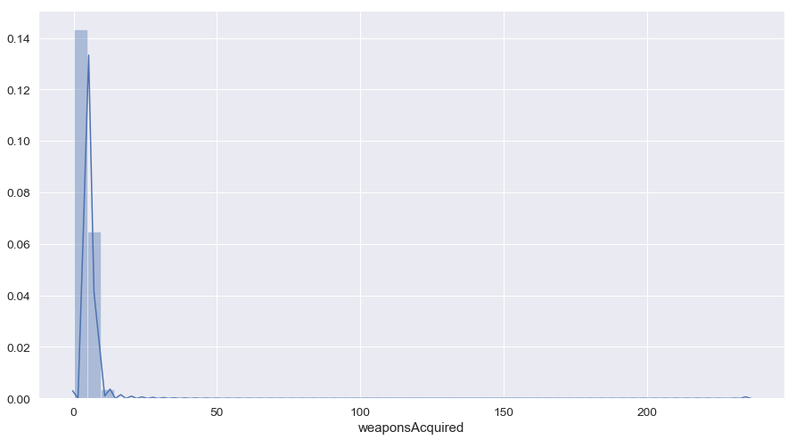

```python
show_distplot('weaponsAcquired')
```

```python
display(train[train['weaponsAcquired'] >= 80].shape)
train[train['weaponsAcquired'] >= 80].head()
```

```
(21, 32)
```

|  | Id | groupId | matchId | assists | boosts | damageDealt | DBNOs | headshotKills | heals | killPlace | ... | swimDistance | teamKills | vehicleDestroys | walkDistance | weaponsAcquired | winPoints | winPlacePerc | _totalDistance | _headshot_rate | _killsWithoutMoving |
| --- | --- | --- | --- | --- | --- | --- | --- | --- | --- | --- | --- | --- | --- | --- | --- | --- | --- | --- | --- | --- | --- |
| 233643 | 7c8c83f5f97d0f | b33b210a52a2f8 | 2e8a0917a71c43 | 0 | 0 | 67.110001 | 0 | 0 | 0 | 44 | ... | 0.000000 | 0 | 0 | 1307.000000 | 128 | 1577 | 0.7111 | 3187.000000 | 0.000000 | False |
| 588387 | c58e3e0c2ba678 | 3d3e6100c07ff0 | d04dbb98249f76 | 0 | 1 | 175.300003 | 1 | 0 | 2 | 48 | ... | 0.000000 | 0 | 0 | 1687.000000 | 80 | 0 | 0.7500 | 1687.000000 | 0.000000 | False |
| 1437471 | 8f0c855d23e4cd | 679c3316056de8 | fbaf1b3ae1d884 | 1 | 0 | 100.000000 | 0 | 0 | 0 | 24 | ... | 47.209999 | 0 | 0 | 2400.000000 | 102 | 0 | 0.8929 | 5299.209961 | 0.000000 | False |
| 1449293 | db54cf45b9ed1c | 898fccaeeb041d | 484b4ae51fe80f | 0 | 0 | 0.000000 | 0 | 0 | 0 | 54 | ... | 0.000000 | 0 | 0 | 653.099976 | 95 | 0 | 0.5600 | 653.099976 | 0.000000 | False |
| 1462706 | be4ff9afaa5bb1 | abb73dd57619fa | f900de1ec39fa5 | 22 | 0 | 5377.000000 | 0 | 8 | 4 | 3 | ... | 0.000000 | 0 | 0 | 1128.000000 | 83 | 0 | 0.8000 | 2082.399902 | 0.150943 | False |

5 rows × 32 columns

```python
# Remove outliers
train.drop(train[train['weaponsAcquired'] >= 80].index, inplace=True)
```

# Anomalies in Heals

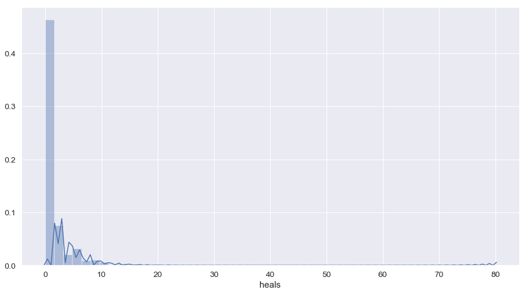

```python
show_distplot('heals')
```

```python
# 40 or more healing items used
display(train[train['heals'] >= 40].shape)
train[train['heals'] >= 40].head(10)
```

```
(135, 32)
```

|  | Id | groupId | matchId | assists | boosts | damageDealt | DBNOs | headshotKills | heals | killPlace | ... | swimDistance | teamKills | vehicleDestroys | walkDistance | weaponsAcquired | winPoints | winPlacePerc | _totalDistance | _headshot_rate | _killsWithoutMoving |
| --- | --- | --- | --- | --- | --- | --- | --- | --- | --- | --- | --- | --- | --- | --- | --- | --- | --- | --- | --- | --- | --- |
| 18405 | 63ab976895d860 | 927eeba5614c4f | 69473402649f11 | 0 | 2 | 0.0 | 0 | 0 | 47 | 43 | ... | 0.000000 | 0 | 0 | 1387.000000 | 6 | 0 | 0.9368 | 6854.000000 | 0.000000 | False |
| 54463 | 069ddee7c9d26a | 58ab5a1ce8e06f | 942416b6caf21e | 1 | 4 | 182.0 | 0 | 1 | 43 | 21 | ... | 292.399994 | 0 | 0 | 2791.000000 | 7 | 0 | 0.9615 | 3083.399902 | 1.000000 | False |
| 126439 | c45bd6917146e2 | 81ab9f863957cb | 4335664c6716fa | 0 | 2 | 0.0 | 0 | 0 | 52 | 49 | ... | 3.443000 | 0 | 0 | 1340.000000 | 3 | 1543 | 0.8333 | 1343.442993 | 0.000000 | False |
| 259351 | 86910c38335c2f | 2738398928d28c | 7d2911e944bfaa | 0 | 10 | 0.0 | 0 | 0 | 42 | 45 | ... | 0.000000 | 0 | 0 | 1510.000000 | 6 | 0 | 0.8646 | 7444.000000 | 0.000000 | False |
| 268747 | a007734fbc6ebf | 5bf702dfa1e5d4 | ad6b5669d33a2c | 0 | 5 | 0.0 | 0 | 0 | 48 | 43 | ... | 0.000000 | 0 | 0 | 1968.000000 | 9 | 0 | 0.8370 | 5816.000000 | 0.000000 | False |
| 269098 | a0891dbc2950ea | dde848d90491ba | b4fd3348551b73 | 0 | 2 | 0.0 | 0 | 0 | 42 | 44 | ... | 0.000000 | 0 | 0 | 2439.000000 | 2 | 1511 | 0.9259 | 2439.000000 | 0.000000 | False |
| 284195 | 91a2fb00455eb3 | f639b09774c5b1 | 65b73c71653822 | 0 | 3 | 123.0 | 0 | 0 | 40 | 52 | ... | 0.000000 | 0 | 0 | 2252.000000 | 8 | 0 | 0.8276 | 4848.000000 | 0.000000 | False |
| 300204 | 1f4f2efc86bfcb | 3d668492d1fca9 | d3638466a43d38 | 0 | 6 | 175.0 | 2 | 1 | 47 | 25 | ... | 0.000000 | 0 | 0 | 2928.000000 | 3 | 1562 | 0.9355 | 3415.600098 | 1.000000 | False |
| 349908 | 7725ad71ad2ff7 | 4b2a7cf86d1546 | cfa2775c9ef944 | 3 | 0 | 2348.0 | 0 | 8 | 41 | 9 | ... | 0.000000 | 0 | 0 | 268.799988 | 33 | 1500 | 0.8889 | 268.799988 | 0.296296 | False |
| 375156 | d64866c78ebcb0 | aa0f089ae6430c | 4dbc4ebba33ec6 | 0 | 7 | 278.5 | 3 | 1 | 44 | 3 | ... | 0.000000 | 0 | 0 | 2489.000000 | 6 | 1517 | 0.9630 | 4927.000000 | 0.250000 | False |

10 rows × 32 columns

```python
# Remove outliers
train.drop(train[train['heals'] >= 40].index, inplace=True)
```

```python
train.shape
```

```
(4349359, 32)
```

```python
train.to_csv('cleaned_data.csv', index=False)
```

```python
cleaned_data = pd.read_csv('cleaned_data.csv')
cleaned_data = reduce_mem_usage(cleaned_data)
```

```
Memory usage of dataframe is 1032.82 MB --> 377.46 MB (Decreased by 63.5%)
```

```python
cleaned_data.head()
```

|  | Id | groupId | matchId | assists | boosts | damageDealt | DBNOs | headshotKills | heals | killPlace | ... | swimDistance | teamKills | vehicleDestroys | walkDistance | weaponsAcquired | winPoints | winPlacePerc | _totalDistance | _headshot_rate | _killsWithoutMoving |
| --- | --- | --- | --- | --- | --- | --- | --- | --- | --- | --- | --- | --- | --- | --- | --- | --- | --- | --- | --- | --- | --- |
| 0 | 7f96b2f878858a | 4d4b580de459be | a10357fd1a4a91 | 0 | 0 | 0.000000 | 0 | 0 | 0 | 60 | ... | 0.00 | 0 | 0 | 244.800003 | 1 | 1466 | 0.4444 | 244.800003 | 0.0 | 0.0 |
| 1 | eef90569b9d03c | 684d5656442f9e | aeb375fc57110c | 0 | 0 | 91.470001 | 0 | 0 | 0 | 57 | ... | 11.04 | 0 | 0 | 1434.000000 | 5 | 0 | 0.6400 | 1445.044556 | 0.0 | 0.0 |
| 2 | 1eaf90ac73de72 | 6a4a42c3245a74 | 110163d8bb94ae | 1 | 0 | 68.000000 | 0 | 0 | 0 | 47 | ... | 0.00 | 0 | 0 | 161.800003 | 2 | 0 | 0.7755 | 161.800003 | 0.0 | 0.0 |
| 3 | 4616d365dd2853 | a930a9c79cd721 | f1f1f4ef412d7e | 0 | 0 | 32.900002 | 0 | 0 | 0 | 75 | ... | 0.00 | 0 | 0 | 202.699997 | 3 | 0 | 0.1667 | 202.699997 | 0.0 | 0.0 |
| 4 | 315c96c26c9aac | de04010b3458dd | 6dc8ff871e21e6 | 0 | 0 | 100.000000 | 0 | 0 | 0 | 45 | ... | 0.00 | 0 | 0 | 49.750000 | 2 | 0 | 0.1875 | 49.750000 | 0.0 | 0.0 |

5 rows × 32 columns

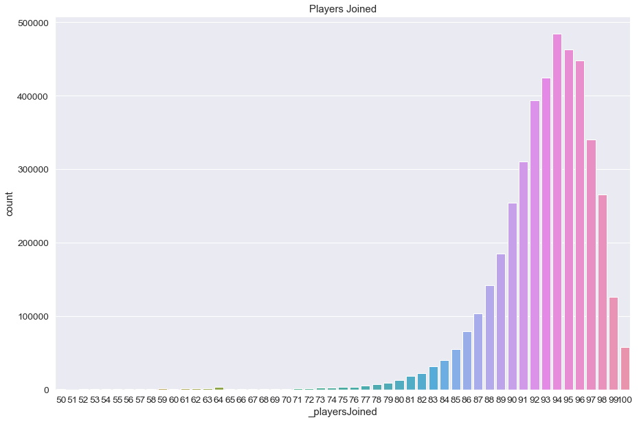

```python
cleaned_data['_playersJoined'] = cleaned_data.groupby('matchId')['matchId'].transform('count')
data = cleaned_data.copy()
data = data[data['_playersJoined']>49]
plt.figure(figsize=(15,10))
sns.countplot(data['_playersJoined'])
plt.title("Players Joined",fontsize=15)
plt.show()
```

```python
# Create normalized features
cleaned_data['_killsNorm'] = cleaned_data['kills']*((100-cleaned_data['_playersJoined'])/100 + 1)
cleaned_data['_damageDealtNorm'] = cleaned_data['damageDealt']*((100-cleaned_data['_playersJoined'])/100 + 1)
cleaned_data['_maxPlaceNorm'] = cleaned_data['maxPlace']*((100-cleaned_data['_playersJoined'])/100 + 1)
cleaned_data['_matchDurationNorm'] = cleaned_data['matchDuration']*((100-cleaned_data['_playersJoined'])/100 + 1)
# Compare standard features and normalized features
to_show = ['Id', 'kills','_killsNorm','damageDealt', '_damageDealtNorm', 'maxPlace', '_maxPlaceNorm', 'matchDuration', '_matchDurationNorm']
cleaned_data[to_show][0:11]
```

|  | Id | kills | _killsNorm | damageDealt | _damageDealtNorm | maxPlace | _maxPlaceNorm | matchDuration | _matchDurationNorm |
| --- | --- | --- | --- | --- | --- | --- | --- | --- | --- |
| 0 | 7f96b2f878858a | 0 | 0.00 | 0.000000 | 0.000000 | 28 | 29.68 | 1306 | 1384.36 |
| 1 | eef90569b9d03c | 0 | 0.00 | 91.470001 | 100.617001 | 26 | 28.60 | 1777 | 1954.70 |
| 2 | 1eaf90ac73de72 | 0 | 0.00 | 68.000000 | 72.760000 | 50 | 53.50 | 1318 | 1410.26 |
| 3 | 4616d365dd2853 | 0 | 0.00 | 32.900002 | 35.861002 | 31 | 33.79 | 1436 | 1565.24 |
| 4 | 315c96c26c9aac | 1 | 1.06 | 100.000000 | 106.000000 | 97 | 102.82 | 1424 | 1509.44 |
| 5 | ff79c12f326506 | 1 | 1.09 | 100.000000 | 109.000000 | 28 | 30.52 | 1395 | 1520.55 |
| 6 | 95959be0e21ca3 | 0 | 0.00 | 0.000000 | 0.000000 | 28 | 28.84 | 1316 | 1355.48 |
| 7 | 311b84c6ff4390 | 0 | 0.00 | 8.538000 | 9.221040 | 96 | 103.68 | 1967 | 2124.36 |
| 8 | 1a68204ccf9891 | 0 | 0.00 | 51.599998 | 54.179998 | 28 | 29.40 | 1375 | 1443.75 |
| 9 | e5bb5a43587253 | 0 | 0.00 | 37.270000 | 40.251600 | 29 | 31.32 | 1930 | 2084.40 |
| 10 | 2b574d43972813 | 0 | 0.00 | 28.379999 | 28.947599 | 29 | 29.58 | 1811 | 1847.22 |

```python
match = cleaned_data.groupby('matchId')
cleaned_data['_killsPerc'] = match['kills'].rank(pct=True).values
cleaned_data['_killPlacePerc'] = match['killPlace'].rank(pct=True).values
cleaned_data['_walkDistancePerc'] = match['walkDistance'].rank(pct=True).values
cleaned_data['_damageDealtPerc'] = match['damageDealt'].rank(pct=True).values
cleaned_data['_walkPerc_killsPerc'] = cleaned_data['_walkDistancePerc'] / cleaned_data['_killsPerc']
cleaned_data.head()
```

|  | Id | groupId | matchId | assists | boosts | damageDealt | DBNOs | headshotKills | heals | killPlace | ... | _playersJoined | _killsNorm | _damageDealtNorm | _maxPlaceNorm | _matchDurationNorm | _killsPerc | _killPlacePerc | _walkDistancePerc | _damageDealtPerc | _walkPerc_killsPerc |
| --- | --- | --- | --- | --- | --- | --- | --- | --- | --- | --- | --- | --- | --- | --- | --- | --- | --- | --- | --- | --- | --- |
| 0 | 7f96b2f878858a | 4d4b580de459be | a10357fd1a4a91 | 0 | 0 | 0.000000 | 0 | 0 | 0 | 60 | ... | 94 | 0.00 | 0.000000 | 29.68 | 1384.36 | 0.297872 | 0.638298 | 0.468085 | 0.148936 | 1.571429 |
| 1 | eef90569b9d03c | 684d5656442f9e | aeb375fc57110c | 0 | 0 | 91.470001 | 0 | 0 | 0 | 57 | ... | 90 | 0.00 | 100.617001 | 28.60 | 1954.70 | 0.250000 | 0.633333 | 0.555556 | 0.433333 | 2.222222 |
| 2 | 1eaf90ac73de72 | 6a4a42c3245a74 | 110163d8bb94ae | 1 | 0 | 68.000000 | 0 | 0 | 0 | 47 | ... | 93 | 0.00 | 72.760000 | 53.50 | 1410.26 | 0.279570 | 0.505376 | 0.344086 | 0.419355 | 1.230769 |
| 3 | 4616d365dd2853 | a930a9c79cd721 | f1f1f4ef412d7e | 0 | 0 | 32.900002 | 0 | 0 | 0 | 75 | ... | 91 | 0.00 | 35.861002 | 33.79 | 1565.24 | 0.274725 | 0.824176 | 0.230769 | 0.296703 | 0.840000 |
| 4 | 315c96c26c9aac | de04010b3458dd | 6dc8ff871e21e6 | 0 | 0 | 100.000000 | 0 | 0 | 0 | 45 | ... | 94 | 1.06 | 106.000000 | 102.82 | 1509.44 | 0.659574 | 0.478723 | 0.180851 | 0.563830 | 0.274194 |

5 rows × 42 columns

```python
corr = cleaned_data[['_killsPerc', '_killPlacePerc','_walkDistancePerc','_damageDealtPerc', '_walkPerc_killsPerc','winPlacePerc']].corr()
```

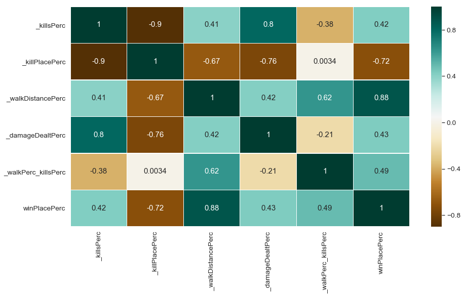

```python
plt.figure(figsize=(15,8))
sns.heatmap(
    corr,
    xticklabels=corr.columns.values,
    yticklabels=corr.columns.values,
    annot=True,
    linecolor='white',
    linewidths=0.1,
    cmap="BrBG"
)
plt.show()
```

```python
agg = cleaned_data.groupby(['groupId']).size().to_frame('players_in_team')
cleaned_data = cleaned_data.merge(agg, how='left', on=['groupId'])
cleaned_data['_healthItems'] = cleaned_data['heals'] + cleaned_data['boosts']
cleaned_data['_headshotKillRate'] = cleaned_data['headshotKills'] / cleaned_data['kills']
cleaned_data['_killPlaceOverMaxPlace'] = cleaned_data['killPlace'] / cleaned_data['maxPlace']
cleaned_data['_killsOverWalkDistance'] = cleaned_data['kills'] / cleaned_data['walkDistance']
cleaned_data['_killsOverDistance'] = cleaned_data['kills'] / cleaned_data['_totalDistance']
cleaned_data['_walkDistancePerSec'] = cleaned_data['walkDistance'] / cleaned_data['matchDuration']
cleaned_data.head()
```

|  | Id | groupId | matchId | assists | boosts | damageDealt | DBNOs | headshotKills | heals | killPlace | ... | _walkDistancePerc | _damageDealtPerc | _walkPerc_killsPerc | players_in_team | _healthItems | _headshotKillRate | _killPlaceOverMaxPlace | _killsOverWalkDistance | _killsOverDistance | _walkDistancePerSec |
| --- | --- | --- | --- | --- | --- | --- | --- | --- | --- | --- | --- | --- | --- | --- | --- | --- | --- | --- | --- | --- | --- |
| 0 | 7f96b2f878858a | 4d4b580de459be | a10357fd1a4a91 | 0 | 0 | 0.000000 | 0 | 0 | 0 | 60 | ... | 0.468085 | 0.148936 | 1.571429 | 4 | 0 | NaN | 2.142857 | 0.000000 | 0.000000 | 0.187443 |
| 1 | eef90569b9d03c | 684d5656442f9e | aeb375fc57110c | 0 | 0 | 91.470001 | 0 | 0 | 0 | 57 | ... | 0.555556 | 0.433333 | 2.222222 | 4 | 0 | NaN | 2.192308 | 0.000000 | 0.000000 | 0.806978 |
| 2 | 1eaf90ac73de72 | 6a4a42c3245a74 | 110163d8bb94ae | 1 | 0 | 68.000000 | 0 | 0 | 0 | 47 | ... | 0.344086 | 0.419355 | 1.230769 | 2 | 0 | NaN | 0.940000 | 0.000000 | 0.000000 | 0.122762 |
| 3 | 4616d365dd2853 | a930a9c79cd721 | f1f1f4ef412d7e | 0 | 0 | 32.900002 | 0 | 0 | 0 | 75 | ... | 0.230769 | 0.296703 | 0.840000 | 1 | 0 | NaN | 2.419355 | 0.000000 | 0.000000 | 0.141156 |
| 4 | 315c96c26c9aac | de04010b3458dd | 6dc8ff871e21e6 | 0 | 0 | 100.000000 | 0 | 0 | 0 | 45 | ... | 0.180851 | 0.563830 | 0.274194 | 1 | 0 | 0.0 | 0.463918 | 0.020101 | 0.020101 | 0.034937 |

5 rows × 49 columns

```python
corr = cleaned_data[['killPlace', 'walkDistance','players_in_team','_healthItems', '_headshotKillRate', '_killPlaceOverMaxPlace', '_killsOverWalkDistance', '_killsOverDistance','_walkDistancePerSec','winPlacePerc']].corr()
```

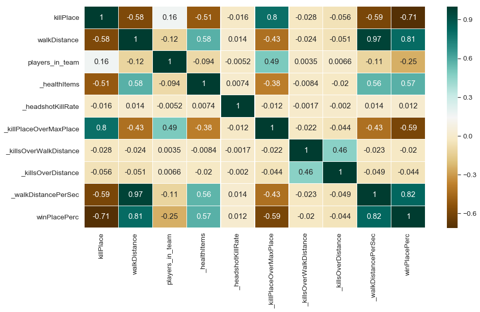

```python
plt.figure(figsize=(15,8))
sns.heatmap(
    corr,
    xticklabels=corr.columns.values,
    yticklabels=corr.columns.values,
    annot=True,
    linecolor='white',
    linewidths=0.1,
    cmap="BrBG"
)
plt.show()
```

```python
cleaned_data.columns
```

```
Index(['Id', 'groupId', 'matchId', 'assists', 'boosts', 'damageDealt', 'DBNOs',
       'headshotKills', 'heals', 'killPlace', 'killPoints', 'kills',
       'killStreaks', 'longestKill', 'matchDuration', 'matchType', 'maxPlace',
       'numGroups', 'rankPoints', 'revives', 'rideDistance', 'roadKills',
       'swimDistance', 'teamKills', 'vehicleDestroys', 'walkDistance',
       'weaponsAcquired', 'winPoints', 'winPlacePerc', '_totalDistance',
       '_headshot_rate', '_killsWithoutMoving', '_playersJoined', '_killsNorm',
       '_damageDealtNorm', '_maxPlaceNorm', '_matchDurationNorm', '_killsPerc',
       '_killPlacePerc', '_walkDistancePerc', '_damageDealtPerc',
       '_walkPerc_killsPerc', 'players_in_team', '_healthItems',
       '_headshotKillRate', '_killPlaceOverMaxPlace', '_killsOverWalkDistance',
       '_killsOverDistance', '_walkDistancePerSec'],
      dtype='object')
```

```python
cleaned_data.drop(['_headshotKillRate','_killsOverDistance', '_killsOverWalkDistance', ], axis=1, inplace=True)
```

```python
cleaned_data.head()
```

|  | Id | groupId | matchId | assists | boosts | damageDealt | DBNOs | headshotKills | heals | killPlace | ... | _matchDurationNorm | _killsPerc | _killPlacePerc | _walkDistancePerc | _damageDealtPerc | _walkPerc_killsPerc | players_in_team | _healthItems | _killPlaceOverMaxPlace | _walkDistancePerSec |
| --- | --- | --- | --- | --- | --- | --- | --- | --- | --- | --- | --- | --- | --- | --- | --- | --- | --- | --- | --- | --- | --- |
| 0 | 7f96b2f878858a | 4d4b580de459be | a10357fd1a4a91 | 0 | 0 | 0.000000 | 0 | 0 | 0 | 60 | ... | 1384.36 | 0.297872 | 0.638298 | 0.468085 | 0.148936 | 1.571429 | 4 | 0 | 2.142857 | 0.187443 |
| 1 | eef90569b9d03c | 684d5656442f9e | aeb375fc57110c | 0 | 0 | 91.470001 | 0 | 0 | 0 | 57 | ... | 1954.70 | 0.250000 | 0.633333 | 0.555556 | 0.433333 | 2.222222 | 4 | 0 | 2.192308 | 0.806978 |
| 2 | 1eaf90ac73de72 | 6a4a42c3245a74 | 110163d8bb94ae | 1 | 0 | 68.000000 | 0 | 0 | 0 | 47 | ... | 1410.26 | 0.279570 | 0.505376 | 0.344086 | 0.419355 | 1.230769 | 2 | 0 | 0.940000 | 0.122762 |
| 3 | 4616d365dd2853 | a930a9c79cd721 | f1f1f4ef412d7e | 0 | 0 | 32.900002 | 0 | 0 | 0 | 75 | ... | 1565.24 | 0.274725 | 0.824176 | 0.230769 | 0.296703 | 0.840000 | 1 | 0 | 2.419355 | 0.141156 |
| 4 | 315c96c26c9aac | de04010b3458dd | 6dc8ff871e21e6 | 0 | 0 | 100.000000 | 0 | 0 | 0 | 45 | ... | 1509.44 | 0.659574 | 0.478723 | 0.180851 | 0.563830 | 0.274194 | 1 | 0 | 0.463918 | 0.034937 |

5 rows × 46 columns

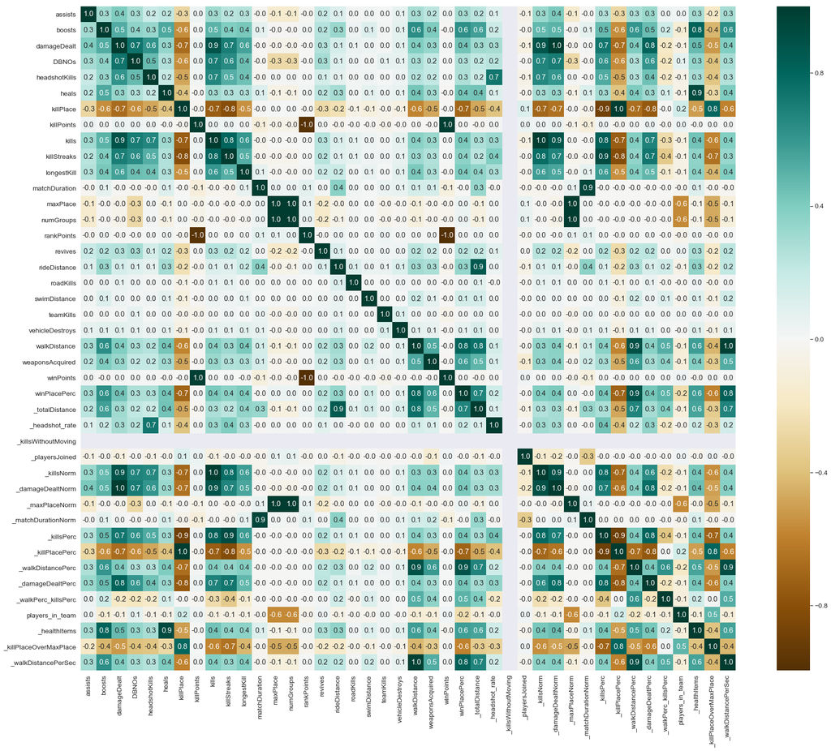

```python
cols_to_fit = [col for col in cleaned_data.columns]
corr = cleaned_data[cols_to_fit].corr()
f,ax = plt.subplots(figsize=(30, 25))
sns.heatmap(cleaned_data[cols_to_fit].corr(), annot=True, fmt= '.1f',ax=ax, cmap="BrBG")
sns.set(font_scale=1.25)
plt.show()
```

## Removing features having 0 correlation with winPlacePerc

```python
cleaned_data.drop(['killPoints','matchDuration','maxPlace','numGroups','rankPoints','roadKills','teamKills','winPoints', '_playersJoined', '_maxPlaceNorm', '_matchDurationNorm', '_killsWithoutMoving'], axis=1, inplace=True)
```

```python
# Now modify the test data
test.head()
```

|  | Id | groupId | matchId | assists | boosts | damageDealt | DBNOs | headshotKills | heals | killPlace | ... | rankPoints | revives | rideDistance | roadKills | swimDistance | teamKills | vehicleDestroys | walkDistance | weaponsAcquired | winPoints |
| --- | --- | --- | --- | --- | --- | --- | --- | --- | --- | --- | --- | --- | --- | --- | --- | --- | --- | --- | --- | --- | --- |
| 0 | 9329eb41e215eb | 676b23c24e70d6 | 45b576ab7daa7f | 0 | 0 | 51.459999 | 0 | 0 | 0 | 73 | ... | 1500 | 0 | 0.0 | 0 | 0.0 | 0 | 0 | 588.000000 | 1 | 0 |
| 1 | 639bd0dcd7bda8 | 430933124148dd | 42a9a0b906c928 | 0 | 4 | 179.100006 | 0 | 0 | 2 | 11 | ... | 1503 | 2 | 4669.0 | 0 | 0.0 | 0 | 0 | 2017.000000 | 6 | 0 |
| 2 | 63d5c8ef8dfe91 | 0b45f5db20ba99 | 87e7e4477a048e | 1 | 0 | 23.400000 | 0 | 0 | 4 | 49 | ... | 1565 | 0 | 0.0 | 0 | 0.0 | 0 | 0 | 787.799988 | 4 | 0 |
| 3 | cf5b81422591d1 | b7497dbdc77f4a | 1b9a94f1af67f1 | 0 | 0 | 65.519997 | 0 | 0 | 0 | 54 | ... | 1465 | 0 | 0.0 | 0 | 0.0 | 0 | 0 | 1812.000000 | 3 | 0 |
| 4 | ee6a295187ba21 | 6604ce20a1d230 | 40754a93016066 | 0 | 4 | 330.200012 | 1 | 2 | 1 | 7 | ... | 1480 | 1 | 0.0 | 0 | 0.0 | 0 | 0 | 2963.000000 | 4 | 0 |

5 rows × 28 columns

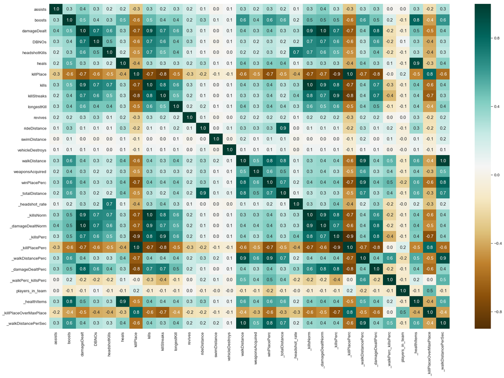

```python
cols_to_fit = [col for col in cleaned_data.columns]
corr = cleaned_data[cols_to_fit].corr()
f,ax = plt.subplots(figsize=(30, 20))
sns.heatmap(corr, annot=True, fmt= '.1f',ax=ax, cmap="BrBG")
sns.set(font_scale=1.25)
plt.show()
```

```python
#saving highly correlated data
cleaned_data.to_csv('Highly_correlated_data.csv', index=False)
```

## Part 4: Final Prediction. Let's have a look at our problem statement and our target variable

Problem Statement: You must create a model which predicts players' finishing placement based on their final stats, on a scale from 1 (first place) to 0 (last place)

Target variable: winPlacePerc - This is a percentile winning placement, where 1 corresponds to 1st place, and 0 corresponds to last place in the match. It is calculated off of maxPlace, not numGroups, so it is possible to have missing chunks in a match.

So our goal is to rank players and our target variable is a percentile.

These two bits are critical pieces of information: the goal tells us what kind of Machine Learning technique we want to use and the target definition tells us about its distribution.

```python
highly_corr = pd.read_csv('Highly_correlated_data.csv')
highly_corr = reduce_mem_usage(highly_corr)
```

```
Memory usage of dataframe is 1128.22 MB --> 468.71 MB (Decreased by 58.5%)
```

```python
X_train = highly_corr[highly_corr['winPlacePerc'].notnull()].reset_index(drop=True)
X_test = highly_corr[highly_corr['winPlacePerc'].isnull()].drop(['winPlacePerc'], axis=1).reset_index(drop=True)
Y_train = X_train.pop('winPlacePerc')
X_test_grp = X_test[['matchId','groupId']].copy()
train_matchId = X_train['matchId']
# drop matchId,groupId
X_train.drop(['matchId','groupId','Id'], axis=1, inplace=True)
X_test.drop(['matchId','groupId','Id'], axis=1, inplace=True)
print(X_train.shape, X_test.shape)
```

```
(4349359, 30) (0, 30)
```

```python
print('There are {} different Match types in the dataset.'.format(highly_corr['matchType'].nunique()))
```

```
There are 3 different Match types in the dataset.
```

```python
# One hot encode matchType
highly_corr = pd.get_dummies(highly_corr, columns=['matchType'])

# Take a look at the encoding
matchType_encoding = highly_corr.filter(regex='matchType')
matchType_encoding.head()
```

|  | matchType_duo | matchType_solo | matchType_squad |
| --- | --- | --- | --- |
| 0 | 0 | 0 | 1 |
| 1 | 0 | 0 | 1 |
| 2 | 1 | 0 | 0 |
| 3 | 0 | 0 | 1 |
| 4 | 0 | 1 | 0 |

```python
# Turn groupId and match Id into categorical types
highly_corr['groupId'] = highly_corr['groupId'].astype('category')
highly_corr['matchId'] = highly_corr['matchId'].astype('category')

# Get category coding for groupId and matchID
highly_corr['groupId_cat'] = highly_corr['groupId'].cat.codes
highly_corr['matchId_cat'] = highly_corr['matchId'].cat.codes

# Get rid of old columns
highly_corr.drop(columns=['groupId', 'matchId'], inplace=True)

# Lets take a look at our newly created features
highly_corr[['groupId_cat', 'matchId_cat']].head()
```

|  | groupId_cat | matchId_cat |
| --- | --- | --- |
| 0 | 609242 | 29996 |
| 1 | 821700 | 32654 |
| 2 | 837266 | 3131 |
| 3 | 1330566 | 45133 |
| 4 | 1744863 | 20468 |

```python
# Drop Id column, because it probably won't be useful for our Machine Learning algorithm,
# because the test set contains different Id's
highly_corr.drop(columns = ['Id'], inplace=True)
```

```python
# Take sample for debugging and exploration
sample = 500000
df_sample = highly_corr.sample(sample)
```

```python
# Split sample into training data and target variable
df = df_sample.drop(columns = ['winPlacePerc']) #all columns except target
y = df_sample['winPlacePerc'] # Only target variable
```

```python
# Function for splitting training and validation data
def split_vals(a, n : int):
    return a[:n].copy(), a[n:].copy()
val_perc = 0.12 # % to use for validation set
n_valid = int(val_perc * sample)
n_trn = len(df)-n_valid
# Split data
raw_train, raw_valid = split_vals(df_sample, n_trn)
X_train, X_valid = split_vals(df, n_trn)
y_train, y_valid = split_vals(y, n_trn)

# Check dimensions of samples
print('Sample train shape: ', X_train.shape,
      'Sample target shape: ', y_train.shape,
      'Sample validation shape: ', X_valid.shape)
```

```
Sample train shape:  (440000, 34) Sample target shape:  (440000,) Sample validation shape:  (60000, 34)
```

```python
# Metric used for the PUBG competition (Mean Absolute Error (MAE))
from sklearn.metrics import mean_absolute_error
from sklearn.ensemble import RandomForestRegressor

# Function to print the MAE (Mean Absolute Error) score

def print_score(m : RandomForestRegressor):
    res = ['mae train: ', mean_absolute_error(m.predict(X_train), y_train),
           'mae val: ', mean_absolute_error(m.predict(X_valid), y_valid)]
    #Score of the training dataset obtained using an out-of-bag estimate.
    if hasattr(m, 'oob_score_'): res.append(m.oob_score_)
    print(res)
```

```python
# Train basic model
m1 = RandomForestRegressor(n_estimators=40, min_samples_leaf=3, max_features='sqrt', n_jobs=-1)
m1.fit(X_train, y_train)
print_score(m1)
```

```
['mae train: ', 0.03101431321928769, 'mae val: ', 0.052009777864556364]
```

```python
def rf_feat_importance(m, df):
    return pd.DataFrame({'cols':df.columns, 'imp':m.feature_importances_}).sort_values('imp', ascending=False)
```

```python
fi = rf_feat_importance(m1, df); fi[:15]
```

|  | cols | imp |
| --- | --- | --- |
| 28 | _walkDistancePerSec | 0.186657 |
| 22 | _walkDistancePerc | 0.160490 |
| 21 | _killPlacePerc | 0.147471 |
| 6 | killPlace | 0.080901 |
| 14 | walkDistance | 0.079363 |
| 16 | _totalDistance | 0.076558 |
| 1 | boosts | 0.051878 |
| 24 | _walkPerc_killsPerc | 0.040150 |
| 9 | longestKill | 0.033452 |
| 27 | _killPlaceOverMaxPlace | 0.030377 |
| 15 | weaponsAcquired | 0.022980 |
| 26 | _healthItems | 0.021951 |
| 20 | _killsPerc | 0.013192 |
| 18 | _killsNorm | 0.008751 |
| 11 | rideDistance | 0.007438 |

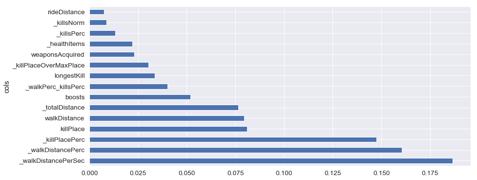

```python
# Plot a feature importance graph for the 20 most important features
plot1 = fi[:15].plot('cols', 'imp', figsize=(14,6), legend=False, kind = 'barh')
plot1
```

```python
X_train.columns
```

```
Index(['assists', 'boosts', 'damageDealt', 'DBNOs', 'headshotKills', 'heals',
       'killPlace', 'kills', 'killStreaks', 'longestKill', 'revives',
       'rideDistance', 'swimDistance', 'vehicleDestroys', 'walkDistance',
       'weaponsAcquired', '_totalDistance', '_headshot_rate', '_killsNorm',
       '_damageDealtNorm', '_killsPerc', '_killPlacePerc', '_walkDistancePerc',
       '_damageDealtPerc', '_walkPerc_killsPerc', 'players_in_team',
       '_healthItems', '_killPlaceOverMaxPlace', '_walkDistancePerSec',
       'matchType_duo', 'matchType_solo', 'matchType_squad', 'groupId_cat',
       'matchId_cat'],
      dtype='object')
```

```python
print(X_train.shape, y_train.shape)
```

```
(440000, 34) (440000,)
```